# Quantitative synthesis: a practical guide on meta-analysis, meta-regression, and publication bias tests for environmental sciences

A step-by-step tutorial along with theoretical explanation

# Preface

This is a step-by-step tutorial, which is a supplement to our methodological guideline paper published in [Environmental Evidence](https://environmentalevidencejournal.biomedcentral.com/) (the official journal of the [Collaboration for Environmental Evidence (CEE)](https://environmentalevidence.org/)).

This tutorial has 5 features.

- It suits many types of readers who have interests and want to learn meta-analytic techniques, from beginners to senior researchers who might already conducted lots of meta-analyses in environmental sciences.
- It can help meta-analysts in many disciplines, albeit the main targets are environmental researchers and we put all technical details in the context of the environmental sciences.
- The illustrative implementation of each method is along with the details in the math, statistical theory, and explanations (more details see main text); in this way, readers can can transfer these methods to the statistical software (e.g., `Python`, `Stata`) with which they are familiar (yes - not necessarily `R`).
- All scripts are well annotated and corresponding outputs are well interpreted.
- We will update this tutorial when necessary. Reader can access the latest version in our [GitHub repository](https://github.com/itchyshin/Meta-analysis_tutorial)

# Credit

We acknowledge that this online tutorial has borrowed some ideas and code from published papers in Prof. Shinichi Nakagawa’s lab ([see full publication list](http://www.i-deel.org/publications.html)) and from (Associate) Prof. Wolfgang Viechtbauer’s versatile `R` package `metafor` ([see the documentation](https://wviechtb.github.io/metafor/), [GitHub page](https://github.com/cran/metafor), and [package webpage](https://www.metafor-project.org/)).

We thanks the the two groups for their good lab culture of Open Science and their advocate of Open Science practices. We also call for more Open Science practices in the environmental sciences, for example, data sharing, code sharing, transparent reporting and open archiving, to make the field more **open**, **reliable**, and **transparent**.

# Citation

If our paper and tutorial have helped you a little bit, please cite the following paper:

> Shinichi Nakagawa, Yefeng Yang, Erin Macartney, Rebecca Spake, and Malgorzata Lagisz. Quantitative synthesis: a practical guide on meta-analysis, meta-regression, and publication bias tests for environmental sciences. Environmental Evidence, 2022.

# Contact

If you have any question or bug reporting, please contact:

- Dr. Yefeng Yang (he/his)

Evolution & Ecology Research Centre, EERC School of Biological, Earth and Environmental Sciences, BEES The University of New South Wales, Sydney, Australia Email: yefeng.yang1@unsw.edu.au

- Professor Shinichi Nakagawa (he/his), PhD, FRSN

Evolution & Ecology Research Centre, EERC School of Biological, Earth and Environmental Sciences, BEES The University of New South Wales, Sydney, Australia Email: s.nakagawa@unsw.edu.au

# Setup `R` in your computer

Our illustrations are based on already available, existing software. So you will need to (freely) download them to let you smoothly follow all illustrations.

The first software you need to install is `R` ([download](https://cran.r-project.org/)) if you have not had it in your computer before . The second is `RStudio` ([download](https://rstudio.com/products/rstudio/)), which can make you have a good experience of using `R`. But `RStudio` is not necessary.

After installation of `R` done, install all the necessary packages. If the packages are archived in CRAN, you will need to use `install.packages()` to install them. For example, for the main package we used - `metafor`, execute `install.packages("metafor")` in the console (bottom left pane of `R Studio`). For packages archived in Github repositories, use `devtools::install_github()` for installation.

Package list: `tidyverse`, `here`, `DT`, `readxl`, `metafor`, `clubSandwich`, `orchaRd`, `MuMIn`, `glmulti`, `metagear`,`stringr`, `mice`,`GoodmanKruskal`,`ggplot2`, `plotly`, `ggthemr`, `cowplot`,`grDevices`,`grid`, `gridGraphics`, `pander`, `formatR`.

You may want to install it while having a cup of coffee because this might take a bit time to finish.

# Load custom functions

We also write some helper functions that can assist the illustrations. Past the source code (included in custom_func.R) into the console, and hit “Enter” to let `R` “learn” these custom functions

# Choosing an effect size statistic

## Brief theory

Biologically, a effect sizes ($z_j$ in the main test) is used to quantify the magnitude or strength of the effect of your interest. Statistically (in the context of meta-analytic model), an effect size serves as the response variable or dependent variable. The choice of effect sizes is primarily dependent on your scientific questions or hypotheses. We categorize effect size statistics into three broad types.

- Single-group effects

A statistical summary form one group; e.g., proportion, mean, log standard deviation (lnSD), log coefficient of variation (lnCV).

- Comparative effects

Comparing statistics between two groups e.g., standardised mean difference (SMD; well known estimators: Hedges’ g or Cohen’s d), log response ratio (lnRR; aka ratio of means), mean difference (MD), risk (proportion) difference (RD), log odds ratio (lnOR), log variability ratio (lnVR), log coefficient of variation ratio (lnCV).

- Association statistics

Relationships between two variables; e.g., Fisher’s z-transformation of correlation correlation coefficient, *r* (*Zr*).

The definition, formulas and explanations of commonly used effect sizes (and their sampling variances, $\nu_j$) can be found in Table 3 in our main text.

## Calculating effect sizes

For a chosen effect size, you can calculate it’s point estimate ($z_j$) and sampling variance ($\nu_j$) using the formulas detailed in Table 3. Alternatively, we can use function `escalc()` in `metafor` package for calculation. Let’s first load the dataset of our first working example from [1], who meta-analysed the intraspecific change in seven morpho‐ecophysiological leaf traits along global elevational gradients.

```
dat_Midolo_2019 <- read.csv(here("data","Midolo_2019_Global Change Biology.csv"))
```

For the purposes of illustration, we only keep the columns that are necessary to show the meta-analytic techniques we elaborate in the main text.

**Table S1**  
The variables in the first worked example ([1]).

|  | Study_ID | study_name | species | trait | treatment | control | sd_treatment | sd_control | n_treatment | n_control | elevation | elevation_log |
| --- | --- | --- | --- | --- | --- | --- | --- | --- | --- | --- | --- | --- |
| 1 | 3 | Bansal and Germino (2010) | Abies lasiocarpa | SLA | 3.283695 | 4.0391003 | 1.145214838 | 0.477685283 | 6 | 6 | 250 | 5.521460918 |
| 2 | 3 | Bansal and Germino (2010) | Abies lasiocarpa | SLA | 3.34668 | 4.0391003 | 0.8584009 | 0.477685283 | 6 | 6 | 430 | 6.063785209 |
| 3 | 3 | Bansal and Germino (2010) | Pseudotsuga menziesii | SLA | 4.740399 | 4.3311516 | 1.049269305 | 0.860446959 | 6 | 6 | 120 | 4.787491743 |
| 4 | 3 | Bansal and Germino (2010) | Pseudotsuga menziesii | SLA | 4.6766827 | 4.3311516 | 1.145215573 | 0.860446959 | 6 | 6 | 430 | 6.063785209 |
| 5 | 34 | Li et al. (2004) | Picea likiangensis | SLA | 9.323157895 | 10.20052632 | 0.526315789 | 0.526315789 | 10 | 10 | 170 | 5.135798437 |
| 6 | 34 | Li et al. (2004) | Picea likiangensis | SLA | 8.444736842 | 10.20052632 | 0.526842105 | 0.526315789 | 10 | 10 | 300 | 5.703782475 |
| 7 | 34 | Li et al. (2004) | Picea asperata | SLA | 8.778947368 | 9.447368421 | 0.737894737 | 0.736842105 | 10 | 10 | 170 | 5.135798437 |
| 8 | 34 | Li et al. (2004) | Picea asperata | SLA | 7.691578947 | 9.447368421 | 0.842631579 | 0.736842105 | 10 | 10 | 300 | 5.703782475 |
| 9 | 38 | Li et al. (2017) | Pinus hwangshanensis | SLA | 9.32328499 | 9.716463518 | 0.191549443 | 0.320331029 | 45 | 45 | 400 | 5.991464547 |
| 10 | 38 | Li et al. (2017) | Pinus hwangshanensis | SLA | 10.30830198 | 9.716463518 | 0.253813486 | 0.320331029 | 45 | 45 | 800 | 6.684611728 |

[output cut: 1284 more lines]

**Table S1** shows extracted/coded variables from published papers. Broadly, these variables can be divided into three types.

You can find more details about the meaning of the variables shown in **Tables S1** in the paper of [1] if you have interests. Without losing generality, we categorize the above variables into three types (see below). We will explain what the role of each variable is when we illustrate the corresponding the meta-analytic techniques we proposed in the main text.

- Bibliometric information

variables are used used as the indices of a paper in online academic databases (e.g., SCOPUS), such as reference name (`study_name`).

- Descriptive statistics

Variables are used to compute effect sizes to quantify seven leaf traits, such as mean (`treatment` and `control`), standard deviation (`sd_treatment` and `sd_control`) and sample size (`n_treatment` and `n_control`).

- Study-related characteristics

Variables that can cause random variability between the effect sizes, such as study identity (`Study_ID`), or systematic variability between the effect sizes, such as treatment characteristics (`evaluation`; which is a independent/predictor/moderator variable).

After having an (primary) understanding of the extracted/coded variables, we can use `escalc()` to compute effect size (using lnRR as an example) with:

```
lnRR <- escalc(measure = "ROM",  # "ROM" means ratio of means; lnRR is specified to be calculated (alternative effect sizes: "SMD" – SMD, "CVR" – lnCVR, "VR" – lnVR; see below);
               m1i = treatment, # mean value of of group 1 (e.g., environmental stressor); in our worked example, m1i denotes the mean value of a trait measured at the higher elevation level;
               m2i = control, # mean value of group 2 (e.g., control); in our worked example, m2i denotes the mean of the same trait measured at the lower elevation level;
               sd1i = sd_treatment, # standard deviation of mean of group 1 (e.g., environmental stressor)
               sd2i = sd_control, # standard deviation of group 2 (e.g., control)
               n1i = n_treatment, # sample size of group 1 (e.g., environmental stressor)
               n2i = n_control, # sample size of group 2 (e.g., control)
               data = dat_Midolo_2019, # dataset containing the above information (here is the dataset of our working example)
               )
```

Let’s have a look at the calculated effect sizes as lnRRs and their sampling variances (Table S2).

**Table S2**  
The point estimate of effect size (**lnRR**) and their sampling variance (**lnRRV**) for each included study and comparison (higher elevation vs. lower elevation).

|  | study_name | lnRR | lnRRV | elevation |
| --- | --- | --- | --- | --- |
| 1 | Bansal and Germino (2010) | -0.207052656418536 | 0.0226031338407557 | 250 |
| 2 | Bansal and Germino (2010) | -0.188053159501089 | 0.0132959119769371 | 430 |
| 3 | Bansal and Germino (2010) | 0.0902878442961859 | 0.0147436342714298 | 120 |
| 4 | Bansal and Germino (2010) | 0.0767555687248802 | 0.0165721302662563 | 430 |
| 5 | Li et al. (2004) | -0.0899379177157685 | 0.00058491300396791 | 170 |
| 6 | Li et al. (2004) | -0.188895930582031 | 0.000655438495869411 | 300 |
| 7 | Li et al. (2004) | -0.0733797180460778 | 0.00131479970424176 | 170 |
| 8 | Li et al. (2004) | -0.20561014160759 | 0.00180848776815669 | 300 |
| 9 | Li et al. (2017) | -0.0413066833375218 | 3.35330712275206e-05 | 400 |
| 10 | Li et al. (2017) | 0.0591278713822637 | 3.76252141054538e-05 | 800 |

[output cut: 1284 more lines]

Note that the argument `measure` is used to specify the types of effect size we choose to quantify the environmental/biological effects. For example, specifying `measure = "SMD"` will compute the point estimate of SMD and its sampling variance. Below, we list the syntax for the most commonly used effect sizes and underappreciated effect sizes. For other types, you can look at the help information of `escalc` by typing `?escalc` in the console of `R`.

- `measure = "ROM"`: lnRR - when you want to quantify the mean difference between two groups
- `measure = "SMD"`: SMD - when you want to quantify the mean difference between two groups
- `measure = "ZCOR"`: *Zr* - when you want to quantify the relationship between two variables
- `measure = "VR"`: lnVR - when you want to quantify the difference in variance between two groups
- `measure = "CVR"`: lnCVR - when you want to quantify the difference in variance between two groups when account for the mean-variance relationship

# Choosing a meta-analytic model

## Two traditional models

After having effect sizes and sampling variance, we can easily answer the **first aim** of an classic environmental meta-analysis - **estimating overall effect**. Traditionally, we use two conventional meta-analytic models, which can be easily fitted via function `rma()` in `metafor`.

- Fixed-effect model (‘common-effect’ or ‘equal-effect’ model; Equation 1)

$$z_{j} = \beta_{0} + m_{j}, (1)\\ m_{j} \sim N(0,\nu_{j})$$
All notations can be found in the main text. The corresponding `R` code is:

```
mod_FE_lnRR <- rma(yi = lnRR, # calculated/estimated effect size are supplied; the outputs of escalc() function;
                   vi = lnRRV, # calculated/estimated sampling variance of lnRR are supplied;
                   method = "EE", # fixed-effect model is specified;
                   data = dat2_Midolo_2019 # our dataset
```

Below is the outputs of our fitted fixed-effect model. **Model Results** show exactly the answers to the **first aim** of an environmental meta-analysis: estimating an overall mean, including the magnitude ($\beta_0$), uncertainty (standard error $SE[\beta_0]$), significance test, and confidence intervals (CIs). We will teach you how to properly interpret all the elements of the above printed model results when we come to the section of our proposed practical model (i.e., multilevel meta-analytic model).

```
Equal-Effects Model (k = 1294)

     logLik     deviance          AIC          BIC         AICc
-18108.6895   41267.0300   36219.3790   36224.5445   36219.3821

I^2 (total heterogeneity / total variability):   96.87%
H^2 (total variability / sampling variability):  31.92

Test for Heterogeneity:
Q(df = 1293) = 41267.0300, p-val < .0001

Model Results:

estimate      se      zval    pval    ci.lb    ci.ub
 -0.0144  0.0004  -34.0926  <.0001  -0.0152  -0.0135  ***

---
Signif. codes:  0 '***' 0.001 '**' 0.01 '*' 0.05 '.' 0.1 ' ' 1
```

- Random-effect model (Equation 2)

Below is the outputs of our fitted random-effect model. Again, we will elaborate on the interpretation in later section.

[output not shown]

It should be noted by fitting the above two traditional models, we treat *k* = 1294 effect sizes in this dataset as independent - which we will later show is wrong.

- **Technical Recommendation**

Setting `method = "REML"` fits a random-effect model using restricted maximum likelihood as a estimator to calculate the maximum likelihood of heterogeneity and corresponding model coefficients (e.g., $\beta_0$). We can also fit a random-effects model with the above syntax but setting the `method` argument to different estimators for calculating heterogeneity: `method = "ML"`: maximum likelihood estimator; `method="DL"` - DerSimonian-Laird estimator; `method = "HE"`: Hedges estimator. **REML** is **recommended overall** because various simulation work demonstrates that it can produce (approximately) unbiased estimate of variance components (e.g., $\tau^2$). It is worth noting that some software do not use REML as the default estimator, such as **Review Manager**, **MetaWin**.

## Multilevel meta-analytic model

### Brief theory

As we explained in the main text, environmental meta-analyses often confront one statistical issue: **non-independence** among data points (i.e., effect sizes) because one study (paper) often contributes multiple effect sizes. To handle the non-independent effect sizes, we propose the simplest and practical meta-analytic model for environmental sciences as:

$$z_{i} = \beta_{0} + \mu_{j[i]} + e_{i} + m_{i}, (3)\\ \mu_{j[i]} \sim
N(0,\tau^2), e_{i} \sim N(0,\sigma^2), m_{i} \sim N(0,\nu_{i})$$
The dataset of [1] (Table S1) has *N* = 71 primary studies with *k* = 1294 effect sizes. *k*/*N* = 18 indicates that this dataset has the issue of statistical dependence. This is because, on average, 18 effect sizes were clustered within the same primary study, leading to them be more similar and correlate with other other. See **Figure 2** in the main text for more situations of statistical non-independence in environmental meta-analysis. The Equation 3 uses an additional random-effect term, within-study effect $e_{i}$ (effect-size level), to account for non-independence due to ‘multiple effect sizes clustering within the same study’ (i.e., clustering).

### Model fitting

From the perspective implementation, we need to handle this non-Independence from the very beginning. When preparing our data file (e.g., Excel or .CSV), we need to structure our data file in a way that permits the incorporation of non-independence among effect sizes. To do so, we need to code a unique identifier for each primary study (`Study_ID`: *S1*, *S2*, *S3*, …) and a unique identifier for each effect size (`ES_ID`: *ES1*, *ES2*, *ES3*, …).

With these coded variables in hand, we can use function `rma.mv` rather than `rma` to fit the multilevel meta-analytic model (Equation 3). Supplying `Study_ID` and `ES_ID` to the argument `random` can construct the two random-effect terms in Equation 3: study level effect $\mu_{j[i]}$ (between-study effect) and effect size level effect $e_{i}$ (within-study effect).

We can use a formula to define the random-effect structure specified in `random`: starts with `~ 1`, followed by a `|`, then a identifier denoting random effects (e.g., `Study_ID` or `ES_ID`). The complete syntax to fit Equation 3 is:

```
mod_ML_lnRR <- rma.mv(yi = lnRR,
                      V = lnRRV,
                      random = list(~1 | Study_ID, # allows true effect sizes to vary among different primary studies - account for the between-study effect and quantify between-study heterogeneity;
                                    ~1 | ES_ID), # allows true effect sizes to vary within primary studies - account for the with-study effect and quantify with-study heterogeneity;
                      method = "REML", # REML is assigned as the estimator for variance components as suggested;
                      data = dat2_Midolo_2019 # our dataset
                      )
```

### Results interpretation

**The classic results of the fitted multilevel model (Equation 3) look:**

```
Multivariate Meta-Analysis Model (k = 1294; method: REML)

   logLik   Deviance        AIC        BIC       AICc
-138.1757   276.3514   282.3514   297.8456   282.3700

Variance Components:

            estim    sqrt  nlvls  fixed    factor
sigma^2.1  0.0191  0.1381     71     no  Study_ID
sigma^2.2  0.0515  0.2269   1294     no     ES_ID

Test for Heterogeneity:
Q(df = 1293) = 41267.0300, p-val < .0001

Model Results:

estimate      se    zval    pval    ci.lb   ci.ub
  0.0297  0.0194  1.5319  0.1255  -0.0083  0.0678

---
Signif. codes:  0 '***' 0.001 '**' 0.01 '*' 0.05 '.' 0.1 ' ' 1
```

Let’s go through the above results one by one.

- **Multivariate Meta-Analysis Model**

`k` = the number of effect sizes (*k*) fed to the multilevel model.

`method: REML` = the REML method was specified as estimation procedure for model fitting to obtain model estimates (e.g., variance components, model coefficients).

`logLik` = restricted log-likelihood of the fitted model,

`Deviance` = goodness-of-fit statistic of the fitted model,

`AIC` = Akaike information criterion score of the fitted model,

`BIC` = Bayesian information criterion and `AICc` (AIC corrected for small sample sizes).

- **Variance Components**

`sigma^2.1` = between-study variance $\tau^2$, which is conceptually equivalent to between-study heterogeneity variance $\tau^2$ in a random-effect model formulated as Equation 2 (but see below for a comparison).

`sigma^2.2` = within-study variance $\sigma^2$.

`estim` = the estimated amount of corresponding variance components.

`sqrt` = standard deviation of variance components.

`nlvls` = how many levels each random effect has.

`factor` = the name of the variables we supply to argument `random` to specify corresponding random effects.

- **Test for Heterogeneity**

Results of hypothesis test of heterogeneity based on Cochran’s Q-test, which is used to test the null hypothesis that all experimental studies have the same/equal effect.

`p-val` < 0.05 = effect sizes derived from the environmental studies are heterogeneous. To put it in other way, the dataset exist substantial heterogeneity.

- **Model Results**

Results of model coefficients and corresponding model inference.

`estimate` = the estimate of pooled/average/overall effect; also as known as grand mean or meta-analytic effect size ($\beta_{0}$ in Equation 3.

`se` = the standard error of the estimate; here, it is (SE[$\beta_{0}$].

`zval` = the value of test statistic (in our case: z-value; see **Technical recommendation** for our recommended practices).

`ci.lb` = lower boundary of (95% by default) confidence intervals (CIs).

`ci.Ub` = upper boundary of CIs.

### Technical recommendation

Argument `test` in `rma.mv` and `rma` is used to specified methods based on which the model inference is conducted; the methods to calculate test statistics and perform significance test of model coefficient like $\beta_0$ (confidence intervals and p-value). **By default**, `rma.mv` and `rma` set `test = "z"`, which meaning that the corresponding model inference is based on a standard normal distribution. However, when meta-analysing small number of studies, setting `test = "z"` will get nominally high Type I error rate, leading to high false positive results. To achieve a nominal performance of tests, it is highly recommended to set `test = "t"`, which uses a t-distribution with *k*−*p* degrees of freedom to test model coefficients (e.g., $\beta_0$) and CIs (*p* = the number of model coefficients). There are also other improved model inferences, for example, adjusting the degrees of freedom of the t-distribution, which can be implemented by setting `dfs = "contain"`.

Therefore, the a multilevel model with improved model inference methods can be fitted with:

```
mod_ML_lnRR <- rma.mv(yi = lnRR,
                      V = lnRRV,
                      random = list(~1 | Study_ID, # allows true effect sizes to vary among different primary studies - account for the between-study effect and quantify between-study heterogeneity;
                                    ~1 | ES_ID), # allows true effect sizes to vary within primary studies - account for the with-study effect and quantify with-study heterogeneity;
                      method = "REML", # REML is assigned as the estimator for variance components as suggested;
                      test = "t", # t-distribution is specified for the tests of model coefficients and CIs;
                      dfs = "contain", # the methods to adjust the (denominator) degrees of freedom;
                      data = dat2_Midolo_2019 # our dataset
                      )
```

As you can see, under **Model Results**, `zval` turns to `tval`. Note that the value has not changed because this worked example has a so large number of primary studies (*N* = 71) that a z-distribution (standard normal distribution) is approximately same as a t-distribution. When the number of primary studies (*N*) is low, setting `test = "t"` and `dfs = "contain"` is highly recommended.

## Statistical non-independence

### Undesirable consequences

Below, by comparing the results of traditional models and our proposed model (i.e., multilevel model), we show how ignoring statistical non-independence (which is a natural consequence if using traditional models) distort the the meta-analytic evidence. Let’s look at Table S3 showing results of traditional models and our proposed model.

**Table S3**  
Comparison of the random-effects and multilevel meta-analytic models.

|  | Random-effect model | Multi-level model |
| --- | --- | --- |
| Overall effect (pooled lnRR) | 0.03 | 0.03 |
| Standard error | 0.01 | 0.02 |
| p-value | 0.0002 | 0.126 |
| Lower CI | 0.01 | -0.01 |
| Upper CI | 0.04 | 0.07 |
| Between-study variance | 0.065 | 0.019 |
| Within-study variance | 0 | 0.052 |
| Between-study heterogeneity I2 (%) | 99.64 | 26.95 |
| Within-study heterogeneity I2 (%) | 0 | 72.73 |

- Distorted results by ignoring statistical non-independence

From Table S3, we can see that conclusions based on our proposed multilevel model conflict with those reached by random-effect model; *p-value* and 95% CIs demonstrate that multilevel model shows statistically non-significant overall effect ($\beta_{0}$), while random-effects model shows statistically significant overall effect ($\beta_{0}$)。

To put it another way, we see that the multilevel model proposed in out main text indeed accounts for statistical non-independence due to multiple effect sizes derived from the same study. We can quantify the degree of dependence using a index - intraclass correlation coefficient:

$$ICC = \frac {\tau^2} {\tau^ + \sigma^2}$$
The *ICC* index can reflect the intraclass correlation of the true effects within the same study. In the above fitted model, the *ICC* can be computed with:

```
mod_ML_lnRR$sigma2[1] / sum(mod_ML_lnRR$sigma2)
```

```
[1] 0.2703379
```

- Neglected results by ignoring statistical non-independence

From Table S3, we can also see that random-effect model leads to neglected results with respect to variance and heterogeneity between effect sizes. This is because random-effect model is likely to exaggerate between-study variance ($\tau^2$). The value of $\tau^2$ in random-effect model (0.065) is three times that in multilevel model (0.019). Random-effect model wrongly distributes within-study variance ($\sigma^2$) to between-study variance ($\tau^2$). Therefore, fitting this dataset using random-effect model will result in a wrong conclusion that there is a high amount of between-study heterogeneity. However, this neglects that there is a large variance and heterogeneity within study ($\sigma^2$ = 0.052 and $I^2_{effect}$ = 72.73; see the calculation of $I^2_{effect}$ in the section **Quantifying & explaining heterogeneity**).

### Variance-covariance matrix

As elaboration in our main text, when multiple effect sizes are derived from a study (paper), there will be two broad types of non-independence (see **Figure 2** for detailed cases):

- non-independence among effect sizes
- non-independence among sampling variances

The multilevel model we proposed (as in Equation 3) only can takes care of cases of non-independence among effect sizes ($z_{i}$). For non-independence among sampling variances ($\nu_{i}$), for example, shared control and measurements, we can construct a variance-covariance matrix to explicitly capture the non-zero covariance ($Cov[\nu_{1[1]},\nu_{1[2]}]=\rho_{12}\sqrt{\nu_{1[1]}\nu_{1[2]}}$) due to correlation between sampling errors ($\nu_{i}$) within the same primary studies:

$$\boldsymbol{M} =
\begin{bmatrix}
\nu_{1[1]} & \rho_{12}\sqrt{\nu_{1[1]}\nu_{1[2]}} & 0 \\
\rho_{21}\sqrt{\nu_{1[2]}\nu_{1[1]}} & \nu_{1[2]} & 0 \\
0 & 0 & \nu_{2[3]}
\end{bmatrix}, (4)$$
Constructing a **VCV** matrix is almost impossible because the within-study sampling correlation (e.g., $\rho_{12}$) are rarely reported in the primary environmental studies, although exact covariances can be computed for some comparative effect statistics (see **Table 2**). But we can impute a **VCV** matrix by assuming a constant $\rho$ across different environmental studies ($\rho_{ik}=\cdots=\rho_{jh}\equiv\rho$). With this simple assumption, we can impute **VCV** matrix via function `impute_covariance_matrix()` in `clubSandwich`:

```
VCV <- impute_covariance_matrix(vi = dat2_Midolo_2019$lnRRV, # sampling variances that are correlated with each within the same study;
                                cluster = dat2_Midolo_2019$Study_ID, # study identity - clustering variable;
                                r = 0.5 # assuming that the effect sizes within the same study are correlated with rho = 0.5.
                                )
```

This also can be done via function `vcalc()` in `metafor`:

```
VCV <- vcalc(vi = lnRRV, # sampling variances that are correlated with each within the same study;
             cluster = Study_ID,  # study identity - clustering variable;
             obs = ES_ID, # different effect sizes corresponding to the same response/dependent variable
             data = dat2_Midolo_2019,
             rho = 0.5 # assuming that the effect sizes within the same study are correlated with rho = 0.5
             )
```

Setting `rho = 0.5` means we assume that sampling errors within the same study are correlated with $\rho$ = 0.5 (see below for **Note**). Let’s see what the imputed **VCV** matrix looks like. Let’s use the Bansal and Germino (2010) as example:

```
      [,1]  [,2]  [,3]  [,4]
[1,] 0.023 0.009 0.009 0.010
[2,] 0.009 0.013 0.007 0.007
[3,] 0.009 0.007 0.015 0.008
[4,] 0.010 0.007 0.008 0.017
```

As shown the above, **VCV** matrix is a symmetric matrix, with the sampling variance ($\nu_{[i]}$) being the diagonal, and the covariance ($Cov[\nu_{i},\nu_{k}]$) being the off-diagonal.

Let’s account for both non-independence among effect sizes and sampling variances:

```
mod_ML_lnRR_var <- rma.mv(yi = lnRR,
                          V = VCV, # use covariance for comparison with that fitted by sampling covariance
                          random = list(~1 | Study_ID,
                                        ~1 | ES_ID),
                          method = "REML",
                          test = "t",
                          data = dat2_Midolo_2019
                          )
```

Then we have a look at whether the model coefficients and corresponding significance tests change:

```
Multivariate Meta-Analysis Model (k = 1294; method: REML)

   logLik   Deviance        AIC        BIC       AICc
-107.3517   214.7034   220.7034   236.1976   220.7220

Variance Components:

            estim    sqrt  nlvls  fixed    factor
sigma^2.1  0.0114  0.1066     71     no  Study_ID
sigma^2.2  0.0516  0.2272   1294     no     ES_ID

Test for Heterogeneity:
Q(df = 1293) = 65913.4258, p-val < .0001

Model Results:

estimate      se    tval    df    pval    ci.lb   ci.ub
  0.0268  0.0170  1.5751  1293  0.1155  -0.0066  0.0602

---
Signif. codes:  0 '***' 0.001 '**' 0.01 '*' 0.05 '.' 0.1 ' ' 1
```

We see that the overall effect ($\beta_0$ = 0.03, 95% CIs = [-0.01 to 0.06]) and corresponding significance tests (*p-value* = 0.1155) do not change after accounting for non-independence among sampling errors. But this does not mean we do not need to account for it.

- **Technical Recommendation**

Certain values of $\rho$ have been recommended by several published papers, for example, setting `rho = 0.5` or a conservative `rho = 0.8`. Overall, we agree these ‘values’ because they make the construction of **VCV** feasible. But we should check the robustness against different values of $\rho$ (see **Conducting sensitivity analysis & critical appraisal** for a pipeline conducting such a sensitivity).

### Robust variance estimation

Robust variance estimation (RVE) can approximate average covariances between sampling errors (and effect sizes) from the data, and then, incorporating such covariances in estimating standard errors (a so-called robust standard error) and making model inference. As we explained in the main text, although RVE can deal with non-independence between both sampling errors and effect sizes, we recommend use RVE in the framework of multilevel model:

- using REV to account for non-independence and make robust model inference
- using multilevel model to partition variance components, which avoids wrong conclusions and provide more insights into heterogeneity

It is very straightforward to implement the combination of RVE and multilevel model - supply the fitted multilevel model (`rma.mv` object) to function `coef_test()` function in `clubSandwich` package:

```
mod_ML_RVE <- coef_test(mod_ML_lnRR_var, # fitted multilevel model for which to make robust model inference (an object of class "rma.mv" can be directly supplied to coef_test());
                       vcov = "CR2", # ‘bias-reduced linearization’ is specified to approximate variance-covariance;
                       cluster = dat2_Midolo_2019$Study_ID # study identity -clusting variable
                       )
```

RVE computes the robust error and use it for the subsequent computation of significance tests (`t-stat`, `p-val`) and confidence intervals of the model coefficients ($\beta_{0}$):

[output not shown]

Alternatively, we can use function `robust()` in `metafor` to implement RVE:

```
robust(mod_ML_lnRR_var,
       cluster = dat2_Midolo_2019$Study_ID,
       clubSandwich = TRUE)
```

[output not shown]

We can see the results of RVE from function `coef_test()` are same as those from function `robust()`.

- **Technical Recommendation**

We do not have definite recommendation on which methods, **VCV** matrix or RVE, to account for non-independence among sampling errors. Because no such simulation work in the context of multilevel meta-analysis has been done so far.

# Quantifying & explaining heterogeneity

## Measuring heterogeneity

The **second aim** of a classic environmental meta-analysis is to **quantify consistencies (heterogeneity) between studies**. In our main text, we recommend two ways of answering this question: absolute and relative heterogeneity measure.

- Absolute heterogeneity measure

We can use variance components such as $\tau^2$, **which can be directly extracted from the outputs of the fitted model** (see section **Results interpretation**); $\tau^2$ in a random-effect model (or $\tau^2$ + $\sigma^2$ in a multilevel model) directly reflects the genuine differences underlying the true effects corresponding to each random effect because the square root can be interpreted as the standard deviation of the true effect sizes. Also, an often neglected insight here is that the sum of the $\tau^2$ and $\sigma^2$ denotes the total amount of variation or heterogeneity in the true effects. In this worked example ([1]), the variation in the true effects ($\tau^2 + \sigma^2$) is 0.0706, which is quite large given the magnitude of the overall effect ($\beta_0$ = 0.0297). Put differently, true effects’ heterogeneity is more than twice the magnitude of true effects (*CV* = 2.37)

- Relative heterogeneity measure

We can use $I^2$ statistic denoting relative variance due to differences between studies (or not due to sampling variance) in the case of random-effect model (Equation 2):

$$I^2=\frac{\tau^2} {\tau^2+\overline{\nu}}, (5)$$
$$\overline{\nu}=\frac{(N_{effect}-1)\sum_{j=1}^{k} 1/\nu_{i}}
{(\sum_{j=1}^{k} 1/\nu_{i})^2-\sum_{j=1}^{k} 1/\nu_{i}^2}, (6)$$

In the case of multilevel model (Equation 3), the formulas can be written as:

$$I^2_{total}=\frac{\tau^2+\sigma^2} {\tau^2+\sigma^2+\overline{\nu}}, (7)$$
$I^2_{total}$ can be further decomposed into variance due to differences between studies ($I^2_{study}$) and variance due to differences within studies ($I^2_{effect}$):

$$I^2_{study}=\frac{\tau^2} {\tau^2+\sigma^2+\overline{\nu}}, (8)$$
$$I^2_{effect}=\frac{\sigma^2} {\tau^2+\sigma^2+\overline{\nu}}, (9)$$
Do not worry about the complexity of these equations because we have developed a function `i2_ml()` (`orchaRd` package) to compute Equations 7 to 9:

```
i2_ml(mod_ML_lnRR_VCV)
```

```
   I2_Total I2_Study_ID    I2_ES_ID
   99.63261    17.97605    81.65656
```

## Explaining variance with meta-regression

### Continuous moderator

The **third aim** of a classic environmental meta-analysis is to **explain the heterogeneity**. To answer this question, we propose to use meta-regression models rather than subgroup analysis (e.g., dividing dataset according to one predictor variable [sex: male vs. female] and conducting separate meta-analyses for each subset). In the context of meta-analysis, we often name a predictor variable as a moderator, indicating that the magnitude of overall effect may be modified in a systematic way as a function of the moderator.

Building upon the multilevel model (Equation 3), a meta-regression model can be constructed by adding one moderator variable (*AKA* predictor, independent/explanatory variable, or fixed factor):

$$z_{i} = \beta_{0} + \beta_{1}x_{1j[i]} + \mu_{j[i]} + e_{i} + m_{i},
(10)\\ \mu_{j[i]} \sim N(0,\tau^2), e_{i} \sim N(0,\sigma^2), m_{i} \sim
N(0,\nu_{i})$$

Model coefficient $\beta_1$, denoting the slope of the moderator variable $x_{1}$, exactly examines how different study characteristics (coded as moderator variable $x_{1}$) mediate the magnitude of the overall effect.

If we have more than one predictor-related hypotheses to test, we can put all the moderator variables into a meta-regression model in a whole, leading to multiple meta-regression (note that post-hoc hypotheses are generally not allowed, so you need to have a clear hypothesis about each predictor rather using the data-driven strategy):

$$z_{i} = \beta_{0} + \sum \beta_{h}x_{h[i]} + \mu_{j[i]} + e_{i} + m_{i},
(11)\\ \mu_{j[i]} \sim N(0,\tau^2), e_{i} \sim N(0,\sigma^2), m_{i} \sim
N(0,\nu_{i})$$

We can fit a (multiple) regression model (as formulated as Equations 10 and 11) using function `rma.mv()`. The moderator, $x_{1}$, can be supplied to the argument `mods` using following formula: starting with a tilde `~`, followed by the name of the moderator (e.g., `mods = ~ x_1`).

In our worked example, [1] examined whether intraspecific leaf trait variation (measured as lnRR) in response to difference in elevation. To answer this question, we can construct a meta-regression model with difference in elevation as a moderator, which is coded as *elevation* column in the dataset (we log-transformed the value of elevation for each study to achieve normality assumption and labelled it as *elevation_log*). Setting `mods = ~ elevation_log` can fit such a meta-regression model with:

```
mod_MLMR_lnRR_elevation <- rma.mv(yi = lnRR,
                                  V = VCV,
                                  mods = ~ elevation_log, # adding elevation as a moderator variable (for continuous variable, it is a good practice to log-transform them to avoid data skewness);
                                  random = list(~1 | Study_ID,
                                                ~1 | ES_ID),
                                  method = "REML",
                                  test = "t",
                                  data = dat2_Midolo_2019,
                                  sparse = TRUE
                                  )
```

The results of the above fitted meta-regression model are very similar with those of a multilevel meta-analytic model (as shown in **Results interpretation** in **Multilevel meta-analytic model**):

```
Multivariate Meta-Analysis Model (k = 1294; method: REML)

   logLik   Deviance        AIC        BIC       AICc
-103.6834   207.3669   215.3669   236.0227   215.3979

Variance Components:

            estim    sqrt  nlvls  fixed    factor
sigma^2.1  0.0098  0.0991     71     no  Study_ID
sigma^2.2  0.0515  0.2269   1294     no     ES_ID

Test for Residual Heterogeneity:
QE(df = 1292) = 65188.5301, p-val < .0001

Test of Moderators (coefficient 2):
F(df1 = 1, df2 = 1292) = 8.0348, p-val = 0.0047

Model Results:

               estimate      se     tval    df    pval    ci.lb    ci.ub
intrcpt         -0.1507  0.0647  -2.3290  1292  0.0200  -0.2776  -0.0238   *
elevation_log    0.0290  0.0102   2.8346  1292  0.0047   0.0089   0.0491  **

---
Signif. codes:  0 '***' 0.001 '**' 0.01 '*' 0.05 '.' 0.1 ' ' 1
```

Here, we only explain results that are different from those from a multilevel meta-analytic model.

- **Test for Residual Heterogeneity**

`QE` = test statistic used to test whether there is a large amount of “residual heterogeneity” among effect sizes. “Residual heterogeneity” means the amount of heterogeneity that is not explained by the included moderator (here is *elevation*).

`p-val` < 0.0001 = residual heterogeneity is still substantial (which is statistically significant larger than that of sampling variance).

- **Test of Moderators (coefficient 2)**

This section denotes omnibus test of all model coefficients or joint test of the null hypotheses:

$$H_0:\beta_0=\beta_1=0$$
`coefficient 2` = 2 coefficients are tested. In our case, intercept ($\beta_0$) and slope ($\beta_1$) of $x_1$ (i.e., *elevation*).

`p-val = 0.0047` = *p-value* of this test, indicating that we can reject the null hypothesis that elevation has a null effect on leaf traits.

- **Model Results**

`intrcpt` = intercept $\beta_0$ in Equation 10. Note that this $\beta_0$ is distinct from $\beta_0$ (i.e., overall effect) in Equations 1 - 3. $\beta_0$ here means the average effect size (lnRR) with a elevation of 0. To put it in another way, setting $x_1$ = 0 can get intercept $\beta_0$.

`elevation_log` = slope $\beta_1$ of $x_1$ (in this case *elevation*), denoting the estimated effect of the tested moderator $x_1$.

With respect to the hypothesis tested in [1], meta-regression confirms that elevation has a positive relationship with intraspcific leaf trait (quantified as lnRR).

### Categorical moderator

As explained in our main text, a categorical moderator also can be incorporated into a meta-regression by creating ‘dummy’ variables representing the various levels/subgroups (see main text for an example). `R` can create dummy variables for us automatically. Therefore, parameterizing a meta-regression with a categorical moderator is the same as meta-regression with a continuous moderator, with one exception: keep or remove intercept (see details below).

Let’ say we aim to investigate whether the effect of elevation differs depending on leaf trait types. This variable is coded as *trait* in the dataset, including 7 levels: specific leaf area (*SLA*), leaf mass per area (*LMA*), leaf area (*LA*), nitrogen concentration per unit of area (*Narea*), nitrogen concentration per unit mass (*Nmass*), phosphorous concentration per unit mass (*Pmass*) and carbon isotope composition (*d13C*).

Traditionally, we would divide the dataset into 7 subgroups and subsequently conduct 7 separate meta-analyses. A more powerful method is to fit a meta-regression with this categorical moderator (*trait*):

```
mod_MLMR_lnRR_trait <- rma.mv(yi = lnRR,
                              V = VCV,
                              mods = ~ trait -1, # setting '-1' is a useful strategy to remove intercept and then directly obtain the estimated effect (slope) for each subgroup or for a particular level within the categorical moderator.
                              random = list(~1 | Study_ID,
                                                ~1 | ES_ID),
                              method = "REML",
                              test = "t",
                              data = dat2_Midolo_2019
                              )
```

The corresponding model output is then:

```
Multivariate Meta-Analysis Model (k = 1294; method: REML)

  logLik  Deviance       AIC       BIC      AICc
-71.6727  143.3454  161.3454  207.7860  161.4863

Variance Components:

            estim    sqrt  nlvls  fixed    factor
sigma^2.1  0.0112  0.1058     71     no  Study_ID
sigma^2.2  0.0486  0.2205   1294     no     ES_ID

Test for Residual Heterogeneity:
QE(df = 1287) = 63967.9953, p-val < .0001

Test of Moderators (coefficients 1:7):
F(df1 = 7, df2 = 1287) = 11.4776, p-val < .0001

Model Results:

               estimate      se     tval    df    pval    ci.lb    ci.ub
I(trait)dC13    -0.0136  0.0243  -0.5596  1287  0.5758  -0.0613   0.0341
I(trait)LA      -0.0672  0.0275  -2.4493  1287  0.0144  -0.1211  -0.0134    *
I(trait)LMA      0.0617  0.0251   2.4566  1287  0.0142   0.0124   0.1109    *
I(trait)Narea    0.0820  0.0243   3.3816  1287  0.0007   0.0344   0.1296  ***
I(trait)Nmass    0.0842  0.0214   3.9409  1287  <.0001   0.0423   0.1261  ***
I(trait)Pmass    0.1633  0.0332   4.9155  1287  <.0001   0.0981   0.2285  ***
I(trait)SLA     -0.0258  0.0241  -1.0702  1287  0.2848  -0.0732   0.0215

---
Signif. codes:  0 '***' 0.001 '**' 0.01 '*' 0.05 '.' 0.1 ' ' 1
```

Now, results under **Test of Moderators** are joint test of null hypotheses for slopes of 7 dummy variables ($\beta_1$ to $\beta_7$; no intercept $\beta_0$ because we remove it via `-1`):

$$H_0:\beta_1=\beta_2=\beta_3=\beta_4=\beta_5=\beta_6=\beta_7=0$$

`p-val < .0001` means the null hypotheses are rejected, suggesting that the trait types as a whole indeed affect the average effect of elevation (there is at least one subgroup showing statistically significant effect).

The results printed under `Model Results` directly give estimated effect for each of 7 traits because removing intercept from model (by `'-1'`) can make all dummy variables be incorporated in the model as moderators. We see that 5 traits (*LA*, *LMA*, *Narea*, *Nmass* and *Pmass*) have statistically significant effects, while the other 2 traits (*dC13* and *SLA*) do not.

- **Technical Recommendation**

Setting `mods = ~ x` (in this case, `mods = ~ trait`) will keep intercept ($\beta_0$) in the model:

```
mod_MLMR_lnRR_trait2 <- rma.mv(yi = lnRR,
                              V = VCV,
                              mods = ~ I(trait),
                              random = list(~1 | Study_ID,
                                            ~1 | ES_ID),
                              method = "REML",
                              test = "t",
                              data = dat2_Midolo_2019
                              )
```

```
Multivariate Meta-Analysis Model (k = 1294; method: REML)

  logLik  Deviance       AIC       BIC      AICc
-71.6727  143.3454  161.3454  207.7860  161.4863

Variance Components:

            estim    sqrt  nlvls  fixed    factor
sigma^2.1  0.0112  0.1058     71     no  Study_ID
sigma^2.2  0.0486  0.2205   1294     no     ES_ID

Test for Residual Heterogeneity:
QE(df = 1287) = 63967.9953, p-val < .0001

Test of Moderators (coefficients 2:7):
F(df1 = 6, df2 = 1287) = 12.9754, p-val < .0001

Model Results:

               estimate      se     tval    df    pval    ci.lb   ci.ub
intrcpt         -0.0136  0.0243  -0.5596  1287  0.5758  -0.0613  0.0341
I(trait)LA      -0.0536  0.0304  -1.7666  1287  0.0775  -0.1132  0.0059    .
I(trait)LMA      0.0753  0.0283   2.6639  1287  0.0078   0.0198  0.1307   **
I(trait)Narea    0.0956  0.0265   3.6063  1287  0.0003   0.0436  0.1477  ***
I(trait)Nmass    0.0978  0.0242   4.0417  1287  <.0001   0.0503  0.1452  ***
I(trait)Pmass    0.1769  0.0354   5.0013  1287  <.0001   0.1075  0.2463  ***
I(trait)SLA     -0.0122  0.0285  -0.4285  1287  0.6684  -0.0681  0.0437

---
Signif. codes:  0 '***' 0.001 '**' 0.01 '*' 0.05 '.' 0.1 ' ' 1
```

By default, `R` alphabetizes the dummy variables. In our case, *dC13* is set as reference level and associated dummy variable is taken out from the meta-regression model. Why *dC13* rather than other dummy variables? Because the letter “b” (*dC13*) comes before other letters, for example, “L” (*LA*) and “S” (SLA). Therefore, model intercept $\beta_{0}$ (`intrcpt`) represents the estimated effect for subgroup of *dC13* ($\beta_0$ = -0.0136, 95CI% = [-0.0613 to 0.0341], *p-value* = 0.5758). The remaining model coefficients denote contrasts between the reference level (`intrcpt` or *dC13*) and the other 6 levels/groups. Therefore, removing intercept (not adding `-1`) can allow us to test whether different levels/subgroups differ in terms of average effect. If we aim to compare estimated effect of one level to other levels, we can set this level as reference by function `relevel()` or `factor()` prior to model fitting. Alternatively, we can use function `anova()` to obtain the contrasts. If you use a subgroup analysis rather than meta-regression to explain heterogeneity, you have to do it by hand: using Wald-type test to calculate the test statistics and then performing significance tests.

## Goodness-of-fit

The goodness-of-fit index $R^2$ can be used to quantify the percentage of variance explained by a moderator. This index has implications of how importance of the examined moderator. It also can be used for model section to select a model with the ‘best’ set of moderators. A general and implement-ready from of $R^2$ is marginal version:

[2] propose to use a general form of $R^2$ - marginal $R^2$, which can be calculated as:

$$R^2_{marginal}=\frac{f^2} {f^2+\tau^2+\sigma^2}, (12) \\ f^2 = Var(\sum
\beta_{h}x_{h[i]}), (13)$$
We wrote a function `r2_ml()` (in `orchaRd` package), which makes the calculation of $R^2_{marginal}$ be done with one line:

```
r2_ml(mod_MLMR_lnRR_elevation)
```

The result given under `R2_marginal` shows that elevation can explain 0.98% of the variation between effect sizes.

```
   R2_marginal R2_conditional
   0.009803104    0.168309094
```

# Notes on visualisation and interpretation

## Classic forest plots

For environmental meta-analyses, a forest is often used to visualize the effect (quantified as effect size) and its 95% CIs for each study and overall effects based on model (e.g., $beta_0$ and its 95% CIs). A classic forest (**Figure S1**) can be made by function `forest()` in `metafor` package:

```
forest(mod_ML_lnRR_VCV, # rma.mv object
       xlab = "Effect size lnRR")
```

On the bottom of the forest plot (**Figure S1**) made by `forest()`, there is a four-sided polygon (well known as ‘diamond’) representing the overall effect based on the fitted model (in our case, *mod_ML_lnRR_VCV* - `rma.mv` object containing outputs of a multilevel model). The center of the diamond denotes the point estimate and the left/right edges correspond to lower and upper CI boundaries. However, we can not clearly see these symbols because the number of studies is very large for this dataset. Although we can use some arguments to make this forest plot clear, it is hard to do so and takes a long time to make it a publish-ready figure. Recently, some new figures deriving from forests can help resolve this issues, such as ‘caterpillar’ plot and ‘orchard’ plot. See **Underappreciated plots**.

[figure not shown]

**Figure S1**  
An example of forest plot showing the effect sizes from each study (and their 95% CIs) and the overall effect based on model.

## Underappreciated plots

Function `orchard_plot()` in `orchaRd` package can make a forest-like plot (termed as ‘orchard’ plot) that can accommodate large number of studies.

A basic orchard plot can be made with:

```
orchard_plot(mod_multilevel_SMD,
             mod = "1",
             xlab = "Standardised mean difference (SMD)",
             group = "Study_ID",  k = TRUE, g = TRUE,
             data = dat2_Midolo_2019) +
             scale_x_discrete(labels = c("Overall effect (meta-analytic lnRR)"))
```

[figure not shown]

**Figure S2**  
Orchard plot (forest-like plot) showing the effect sizes from each study (and their 95% CIs), the overall effect and its 95% CIs and 95% prediction intervals.

We see that an orchard plot looks more informative than a classic forest plot. For example, it can show the distribution of the effect size from each study, the number of effect sizes (*k*) and the number of studies (the number in the bracket). A orchard plot not only can visualize the meta-analytic results, but also let us realize something we are not bale to see from statistical results, such as influential data points and outliers that could threaten the robustness of our results. Further, an orchard plot not only show 95% CIs (thick whiskers in **Figure S2**) but also 95% prediction intervals (PIs; thin whiskers), through which we can visually check the heterogeneity among effect sizes. Because CIs only include the standard error of the overall effect $\beta_0$ ($SE[\beta_0]$), which PIs include variance of random effects:

$$\text{95%CI} = \beta_{0} \pm t_{df[\alpha=0.05]} SE[\beta_{0}^2], (14)$$

$$\text{95%PI} = \beta_{0} \pm t_{df[\alpha=0.05]} \sqrt{\tau^2+\sigma^2+
SE[\beta_{0}^2]}, (15)$$
If you want to know the detailed value of PIs, you can use `predict`:

```
   pred     se   ci.lb  ci.ub   pi.lb  pi.ub
 0.0268 0.0170 -0.0066 0.0602 -0.4667 0.5203
```

- **Visualize meta-regression with a categorical moderator**

A fabulous function of `orchard_plot()` is that it also can nicely show results based on meta-regression model (**Figure S3**). The results based on meta-regression with *trait* as a moderator can be visualized with:

```
orchard_plot(mod_MLMR_lnRR_trait,
             mod = "trait",
             xlab = "Effect size lnRR",
             group = "Study_ID",  k = TRUE, g = TRUE, trunk.size = 1.5,
             data = dat2_Midolo_2019) +
             scale_x_discrete(labels = c("SLA","Pmass","Nmass","Narea","LMA","LA","dC13"))
```

[figure not shown]

**Figure S3**  
Orchard plot (forest-like plot) showing the effect sizes from each study and the overall effect for each subgroup/levels of a given categorical moderator.

- **Visualize meta-regression with a continuous moderator**

For a meta-regression with a continuous moderator, we can use `bubble_plot()` to visualize the results. Let’s visualize the meta-regression with *elevation* as the continuous moderator:

```
bubble_plot(mod_MLMR_lnRR_elevation,
            mod = "elevation_log",
            xlab = "Elevation (log-transformed)", ylab = "Effect size lnRR",
            group = "Study_ID",k = TRUE, g = TRUE,
            data = dat2_Midolo_2019, legend.pos = "top.left") +
            theme(axis.text.x = element_text(size = 12, colour = "black"),
                  axis.text.y = element_text(size = 12, colour = "black"),
                  axis.title.x = element_text(size = 12, colour = "black"),
                  plot.title = element_text(size = 12, colour = "black"))
```

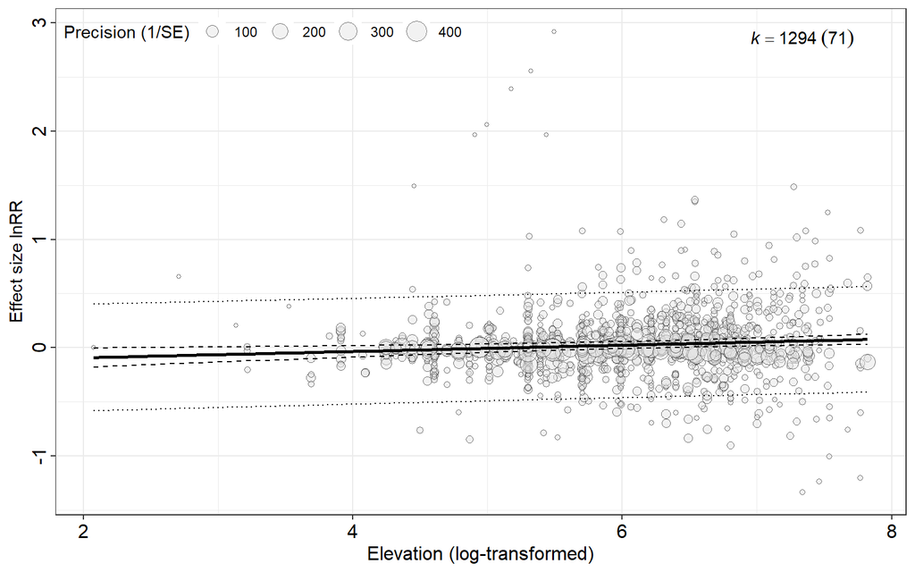

**Figure S4**  
Bubble plot showing the results of a meta-regression model: relationship between a continuous moderator (in our case, *elevation*) and effect size magnitude (lnRR).

# Checking for publication bias and robustness

## Detecting and correcting for publication bias

- **Detecting small study effect**

The first form publication bias is **small study effect** where an effect size value from a small-sample-sized study (large uncertainty and low precision) can be much larger in magnitude than a ‘true’ effect. A straightforward way to detect small study effect is to add the uncertainty of effect size as a moderator, such that the relationship between effect size and its uncertainty can be quantified. We propose to formulate Egger’s regression (which is a classic method to detect the symmetry of a funnel plot) in the framework multilevel model to detect the small-study effect for dependent effect sizes:

$$z_{i} = \beta_{0} + \beta_1\sqrt{\frac {1} {\tilde{n_i}}} + \mu_{j[i]} +
e_{i} + m_{i}, (16)$$
$$z_{i} = \beta_{0} + \beta_1(\frac {1} {\tilde{n_i}}) + \mu_{j[i]} +
e_{i} + m_{i}, (17)$$

Sampling error $\sqrt{\nu_i}$ is a typical uncertainty measure of effect size $z_{i}$. However, for some types of effect size, for example, SMD and lnRR, $z_{i}$ has a intrinsic relationship with its $\nu_i$ (see **Table 2**). Therefore, $\nu_i$ is not a preferred moderator to detect small-study effect. In Equation 16, we use an undated sampling error based on effective sample size $\tilde{n}$ as the moderator. Let’s calculate $\tilde{n} = \frac {n_{iC}n_{iT}} {n_{iC}+n_{iT}}$ for lnRR in our example (see **Table 2** for formulas for other effect sizes):

```
ess.var_cal <- function(dat){1/dat$n_control + 1/dat$n_treatment} # write a help function to calculate adapted sampling variance based on effective size based  - tilde n
dat2_Midolo_2019$ess.var <- ess.var_cal(dat2_Midolo_2019) # calculate tilde N
dat2_Midolo_2019$ess.se <- sqrt(dat2_Midolo_2019$ess.var) # calculate adapted sampling error based on effective size - tilde square root n
```

Then the Equation 16 can be fitted with:

```
mod_MLMR_lnRR_ess.se <- rma.mv(yi = lnRR,
                               V = VCV,
                               mods = ~ ess.se, # add adjusted based sampling error - tilde square root n as a moderator to test small study effect.
                               random = list(~1 | Study_ID,
                                             ~1 | ES_ID),
                               method = "REML",
                               test = "t",
                               data = dat2_Midolo_2019
                               )
```

The outputs of the above fitted model are exactly the same as those of a meta-regression model:

```
Multivariate Meta-Analysis Model (k = 1294; method: REML)

   logLik   Deviance        AIC        BIC       AICc
-106.2100   212.4201   220.4201   241.0758   220.4511

Variance Components:

            estim    sqrt  nlvls  fixed    factor
sigma^2.1  0.0112  0.1060     71     no  Study_ID
sigma^2.2  0.0516  0.2272   1294     no     ES_ID

Test for Residual Heterogeneity:
QE(df = 1292) = 65891.3832, p-val < .0001

Test of Moderators (coefficient 2):
F(df1 = 1, df2 = 1292) = 1.6336, p-val = 0.2014

Model Results:

         estimate      se     tval    df    pval    ci.lb   ci.ub
intrcpt   -0.0353  0.0515  -0.6865  1292  0.4925  -0.1364  0.0657
ess.se     0.1231  0.0963   1.2781  1292  0.2014  -0.0658  0.3120

---
Signif. codes:  0 '***' 0.001 '**' 0.01 '*' 0.05 '.' 0.1 ' ' 1
```

If you followed the early sections of this tutorial carefully, We guess you already can interpret the results by yourself. Yes, look at `ess.se` given under **Model Results**: *p-value* and 95% CIs show that effect size has no statistical relationship between its error, meaning that no small study effect exits. The bubble plot (**Figure S5**) also indicates that there is no visual correlation between effect size and its error - effect size symmetrically distribute on the funnel plot (**Figure S6**).

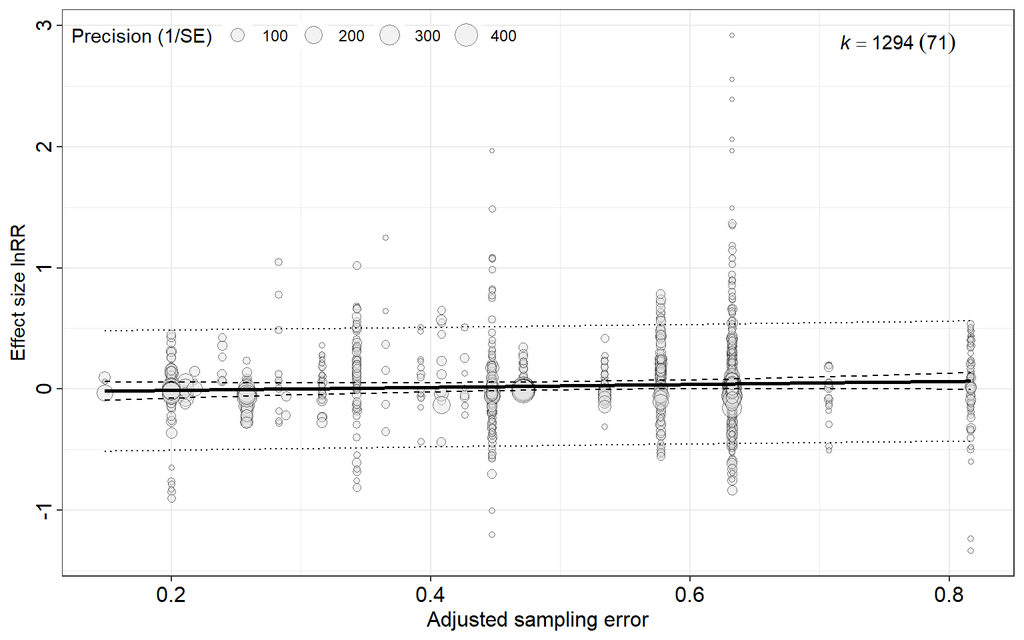

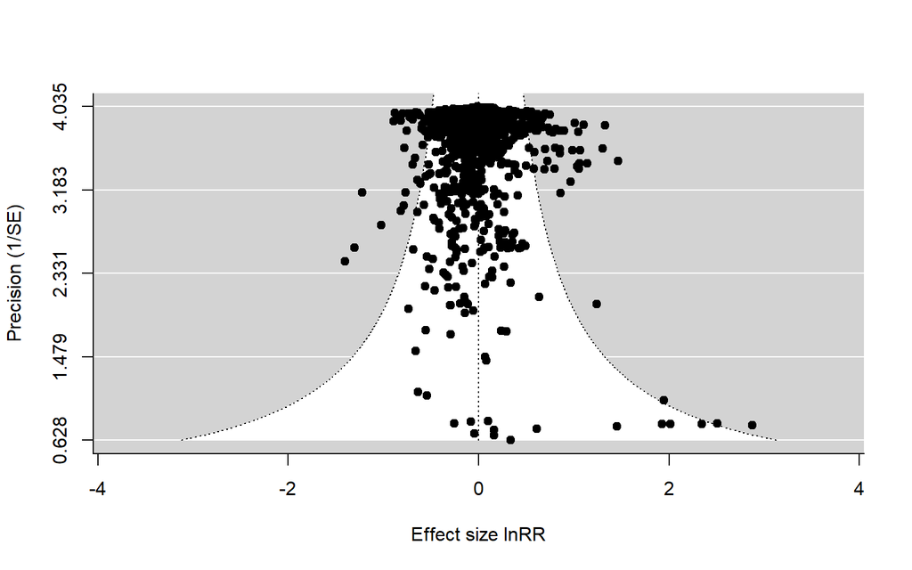

**Figure S6**  
Visual inspection of the funnel plot to identify the small study effect.

- **Detecting decline effect**

Decline effect, also known as time-lag bias, is the second form of publication bias where effect sizes tend to get closer to zero over time. Testing decline effect is important because the temporal changes in evidence of a given field poses a threat to environmental policy-making, management, and practices. Decline effect can be tested by a meta-regression with publication year (centered to ease interpretation: $c(year_{j[i]})$) as a moderator:

$$z_{i} = \beta_{0} + \beta_1c(year_{j[i]}) + \mu_{j[i]} + e_{i} + m_{i},
(18)$$
Equation 18 can be fitted with code:

```
mod_MLMR_lnRR_Year.c <- rma.mv(yi = lnRR,
                               V = VCV,
                               mods = ~ Year.c, # add centered year as a moderator to detect decline effect.
                               random = list(~1 | Study_ID,
                                             ~1 | ES_ID),
                               method = "REML",
                               test = "t",
                               data = dat2_Midolo_2019,
                               sparse = TRUE
                               )
```

As you see in the following results,regression slope is `Year.c` = 0.002 (95% CIs = [-0.0022 to 0.0062]), which is very small and not statistically different from zero (`t_value` = 0.9135 and `p-val` = 0.3611), suggesting studies with statistically significant results do not publish earlier than these with statistically non-significant results results, i.e. no time-lag bias (**Figure S7**).

```
Multivariate Meta-Analysis Model (k = 1294; method: REML)

   logLik   Deviance        AIC        BIC       AICc
-106.5039   213.0079   221.0079   241.6637   221.0390

Variance Components:

            estim    sqrt  nlvls  fixed    factor
sigma^2.1  0.0114  0.1067     71     no  Study_ID
sigma^2.2  0.0517  0.2273   1294     no     ES_ID

Test for Residual Heterogeneity:
QE(df = 1292) = 65896.5620, p-val < .0001

Test of Moderators (coefficient 2):
F(df1 = 1, df2 = 1292) = 0.8345, p-val = 0.3611

Model Results:

         estimate      se    tval    df    pval    ci.lb   ci.ub
intrcpt    0.0267  0.0170  1.5668  1292  0.1174  -0.0067  0.0601
Year.c     0.0020  0.0021  0.9135  1292  0.3611  -0.0022  0.0062

---
Signif. codes:  0 '***' 0.001 '**' 0.01 '*' 0.05 '.' 0.1 ' ' 1
```

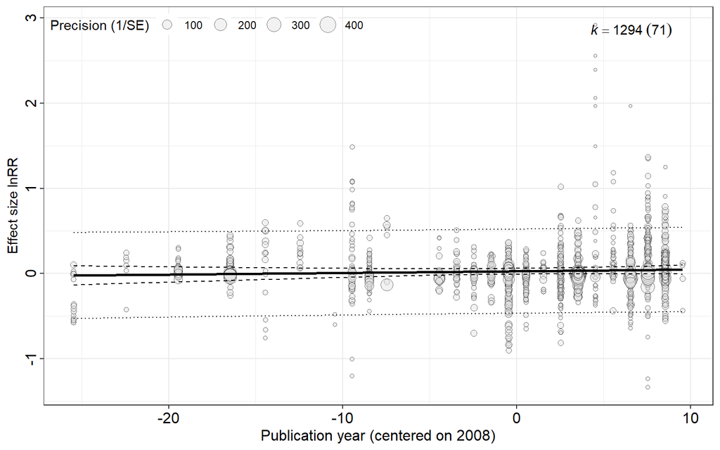

**Figure S7**  
Bubble plot showing the relationship between the effect size magnitude and publication year (centered on 2008). There is no temporal trend in the changes of the effect size magnitude.

- **Correcting for publication bias**

Besides detecting publication bias, it is necessary to correct for such a bias to check the robustness of model estimates. Intercept $\beta_{0}$ in Equation 17 can be interpreted as the publication-bias-corrected overall effect (‘true’ effect). Because $\beta_{0}$ is the model coefficient when setting $\frac {1} {\tilde{n}}$ = 0, which means the dataset has a infinite sample size (high precision) and thus has no small-study effect. To obtain publication-bias-corrected overall effect, we need to fit Equation 17 with:

```
mod_MLMR_lnRR_ess.var <- rma.mv(yi = lnRR,
                                V = VCV,
                                mods = ~ ess.var, # adding adjusted sampling error to obtain publication-bias-corrected overall effect - which is potentially regarded as 'true' effect.
                                random = list(~1 | Study_ID,
                                              ~1 | ES_ID),
                                method = "REML",
                                test = "t",
                                data = dat2_Midolo_2019,
                                sparse = TRUE
                                )
```

`intrcpt` printed under **Model Results** shows that intercept $\beta_0$ (-0.0029, 95% CIs = [-0.0659 to 0.0602]) is still statistically non-significant (*p-value* = 0.9285), although the magnitude and direction change. This suggests that the meta-analytic estimate of this dataset ([1]) is robust to publication bias (**Table S4**).

```
Multivariate Meta-Analysis Model (k = 1294; method: REML)

   logLik   Deviance        AIC        BIC       AICc
-106.4500   212.8999   220.8999   241.5557   220.9310

Variance Components:

            estim    sqrt  nlvls  fixed    factor
sigma^2.1  0.0113  0.1065     71     no  Study_ID
sigma^2.2  0.0516  0.2272   1294     no     ES_ID

Test for Residual Heterogeneity:
QE(df = 1292) = 65878.9167, p-val < .0001

Test of Moderators (coefficient 2):
F(df1 = 1, df2 = 1292) = 1.1843, p-val = 0.2767

Model Results:

         estimate      se     tval    df    pval    ci.lb   ci.ub
intrcpt   -0.0029  0.0321  -0.0897  1292  0.9285  -0.0659  0.0602
ess.var    0.1048  0.0963   1.0883  1292  0.2767  -0.0841  0.2937

---
Signif. codes:  0 '***' 0.001 '**' 0.01 '*' 0.05 '.' 0.1 ' ' 1
```

**Table S4** Comparison of original meta-analytic estimates and bias-corrected meta-analytic estimates.

|  | Original estimate | Bias-corrected estimate |
| --- | --- | --- |
| Overall effect | 0.0268 | -0.0029 |
| Standard error | 0.017 | 0.0321 |
| p-value | 0.115 | 0.929 |
| Lower CI | -0.0066 | -0.0659 |
| Upper CI | 0.0602 | 0.0602 |

**Accounting for heterogeneity when detecting publication bias**

In our main text, We introduce Equation 19 to simultaneously detect two forms of publication bias while account for heterogeneity to increase power and reduce Type I error rate:

$$z_{i} = \beta_{0} + \beta_1\sqrt{\frac {1} {\tilde{n_i}}} +
\beta_2c(year_{j[i]}) + \sum \beta_{h}x_{h[i]} + \mu_{j[i]} + e_{i} +
m_{i}, (19)$$
To fit Equation 19 via `rma.mv`, we only need to put adapted sampling error ($\beta_1\sqrt{\frac {1} {\tilde{n_i}}}$), publication year ($c(year_{j[i]}$) and other important study characteristics as moderator variables in a meta-regression (e.g., multiple meta-regression; see section **Explaining variance with meta-regression**). We arbitrarily select *elevation* and *trait* as moderators to show the implementation:

```
Multivariate Meta-Analysis Model (k = 1294; method: REML)

  logLik  Deviance       AIC       BIC      AICc
-67.0224  134.0449  158.0449  219.9377  158.2904

Variance Components:

            estim    sqrt  nlvls  fixed    factor
sigma^2.1  0.0099  0.0996     71     no  Study_ID
sigma^2.2  0.0486  0.2204   1294     no     ES_ID

Test for Residual Heterogeneity:
QE(df = 1284) = 63164.1842, p-val < .0001

Test of Moderators (coefficients 1:10):
F(df1 = 10, df2 = 1284) = 8.9597, p-val < .0001

Model Results:

               estimate      se     tval    df    pval    ci.lb    ci.ub
ess.var          0.0119  0.0936   0.1275  1284  0.8985  -0.1717   0.1956
Year.c           0.0021  0.0021   1.0005  1284  0.3172  -0.0020   0.0061
elevation_log    0.0284  0.0100   2.8385  1284  0.0046   0.0088   0.0481   **
traitdC13       -0.1900  0.0707  -2.6891  1284  0.0073  -0.3286  -0.0514   **
traitLA         -0.2446  0.0713  -3.4329  1284  0.0006  -0.3844  -0.1048  ***
traitLMA        -0.1165  0.0710  -1.6399  1284  0.1013  -0.2559   0.0229
traitNarea      -0.0962  0.0708  -1.3597  1284  0.1742  -0.2351   0.0426
traitNmass      -0.0939  0.0699  -1.3432  1284  0.1795  -0.2311   0.0433
traitPmass      -0.0150  0.0746  -0.2016  1284  0.8403  -0.1614   0.1313
traitSLA        -0.2035  0.0698  -2.9160  1284  0.0036  -0.3404  -0.0666   **

---
Signif. codes:  0 '***' 0.001 '**' 0.01 '*' 0.05 '.' 0.1 ' ' 1
```

From the follow model outputs, we see that the slopes of $\sqrt{\frac {1} {\tilde{n_i}}}$ ($\beta_1$) and $c(year_{j[i]}$ ($\beta_2$) still remain non-significant, albeit changes in magnitude , confirming that there is no publication bias.

## Conducting sensitivity analysis & critical appraisal

- **Sensitivity of assumption of within-study (sampling) correlation**

Here, we show how to perform a sensitivity analysis to examine the extent to which the overall effect (e.g., $\beta_{0}$) is sensitive to the assumption of within-study (sampling) correlation $\rho$ values used for constructing variance-covariance matrix (VCV).

First, set a series of $\rho$ (i.e., 0.3, 0.5, 0.7, 0.9) (we assume these values arbitrarily; you can set them based on your expertise in your field):

```
rho_range <- c(0.3, 0.5, 0.7, 0.9)
```

Then, we write a function to help repeatedly run the specified model, changing $\rho$ at a time:

```
ML_VCV_range <- list() # repeatedly run the specified model with varying rho
for (i in 1:length(rho_range)) {

VCV_range <- vcalc(vi = lnRRV,
             cluster = Study_ID,
             obs = ES_ID,
             data = dat2_Midolo_2019,
             rho = rho_range[i]) # impute VCV matrix with variying rho

ML_VCV_range[[i]] <- rma.mv(yi = lnRR,
                            V = VCV_range, # VCV matrix with varying values of rho.
                            random = list(~1 | Study_ID,
                                          ~1 | ES_ID),
                            method = "REML",
                            test = "t",
                            data = dat2_Midolo_2019
                           )} # run model with different rho values.
```

From **Table S5**, we see that the overall effect $\beta_{0}$ does not change with the changing of $\rho$ values, indicating that the model estimates are robust to different assumption of $\rho$.

**Table S5** Sensitivity analysis examing the robustness ofthe overall effect (i.e., $\beta_0$) to the assumption of $\rho$ values.

|  | Correlation (ρ) | Overall effect | Standard error | p-value | Lower CI | Upper CI |
| --- | --- | --- | --- | --- | --- | --- |
| 1 | 0.3 | 0.0276825859866493 | 0.0175609021544498 | 0.115183775789385 | -0.0067683984833436 | 0.0621335704566423 |
| 2 | 0.5 | 0.0267950267963954 | 0.0170115447357322 | 0.11547605614107 | -0.00657822808235798 | 0.0601682816751487 |
| 3 | 0.7 | 0.0260531220781403 | 0.0167402218215044 | 0.119877017155391 | -0.00678785140514684 | 0.0588940955614274 |
| 4 | 0.9 | 0.0257600111713718 | 0.0166959669153564 | 0.123102583921393 | -0.00699414302034266 | 0.0585141653630862 |

- **Leave-one-out analysis**

The sensitivity analysis (robustness of results) also can be conducted by repeatedly fitting the model based on the dataset with one unit/entry (e.g., study) deleted at a time. This method is known as leave-one-out analysis. ‘One unit/entry’ denotes a row from the dataset fed to the model. Primary study included in the dataset is the typical ‘one unit/entry’. Leave-one-out analysis is a useful method to diagnose outlier and influential studies (which exert disproportionate influence on model estimates like overall effect $\beta_0$ and its 95% CIs). As you might imagine, leave-one-out analysis re-fit the model *N* (the number of study) times. So it may take quite a long time to finish such a analysis if you have a large *N*.

For fixed and random effects models, the implementation of leave-one-out analysis can be easily performed via `leave1out()` function in `metafor`. The syntax is just one line:

```
leave1out(mod_FE_lnRR)
```

Let’s have a look at the results of the first 10 rows:

```
   estimate     se     zval   pval   ci.lb   ci.ub          Q     Qp      I2
1   -0.0144 0.0004 -34.0889 0.0000 -0.0152 -0.0135 41265.3873 0.0000 96.8690
2   -0.0144 0.0004 -34.0869 0.0000 -0.0152 -0.0135 41264.7609 0.0000 96.8690
3   -0.0144 0.0004 -34.0954 0.0000 -0.0152 -0.0135 41266.2873 0.0000 96.8691
4   -0.0144 0.0004 -34.0948 0.0000 -0.0152 -0.0135 41266.5291 0.0000 96.8691
5   -0.0143 0.0004 -34.0330 0.0000 -0.0152 -0.0135 41257.2615 0.0000 96.8684
6   -0.0143 0.0004 -33.9758 0.0000 -0.0151 -0.0135 41220.5405 0.0000 96.8656
7   -0.0144 0.0004 -34.0714 0.0000 -0.0152 -0.0135 41264.3804 0.0000 96.8690
8   -0.0143 0.0004 -34.0464 0.0000 -0.0152 -0.0135 41246.8031 0.0000 96.8676
9   -0.0142 0.0004 -33.6629 0.0000 -0.0150 -0.0134 41245.2609 0.0000 96.8675
10  -0.0147 0.0004 -34.8368 0.0000 -0.0155 -0.0139 41122.8168 0.0000 96.8582
        H2
1  31.9392
2  31.9387
3  31.9399
4  31.9400
5  31.9329
6  31.9044
7  31.9384
8  31.9248
9  31.9236
10 31.8288
```

For our proposed multilevel model, no existing packages or functions are ready to use. But you can modify the following code to implement leave-one-out analysis in the framework of multilevel model. Later, we will write a corresponding function and wrap it into `orchaRd` package. The syntax for using study as unit deleted at a time is:

```
dat2_Midolo_2019$leave_out <- as.factor(dat2_Midolo_2019$study_name) # create the variable that will be left out
leave1out_ES <- list() # create a list to contain model estimates
for(i in 1:length(levels(dat2_Midolo_2019$leave_out))){
  # create the data with one study removed at a time
  dat <- dat2_Midolo_2019 %>% filter(leave_out != levels(dat2_Midolo_2019$leave_out)[i]) # repeatedly run the multilevel model, leaving out one study at a time

  VCV_leave1out <- list()
  VCV_leave1out[[i]] <- impute_covariance_matrix(vi = dat$lnRRV, cluster = dat$Study_ID, r = 0.5)  # create a list of VCV matrices for following model fitting

  leave1out_mod[[i]] <- rma.mv(yi = lnRR,
                                 V = VCV_leave1out[[i]],
                                 random = list(~1 | Study_ID,
                                               ~1| ES_ID),
                                 method = "REML",
                                 test = "t",
                                 data = dat,
                                 sparse = TRUE)} # model fitting


est.func <- function(mod){
  df <- data.frame(est = mod$b, lower = mod$ci.lb, upper = mod$ci.ub)
  return(df)
} # write a simple function to extract intercept and 95% CIs from each of the above fitted models

leave1out_results <- lapply(leave1out_mod, function(x) est.func(x)) %>% bind_rows %>% mutate(left_out = levels(dat2_Midolo_2019$leave_out)) # turn the model estimates in the format of data frame
```

The results of leave-one-out analysis are shown on **Figure S8**, from which we see that there seems no outlier and influential study obviously affecting the model estimates.

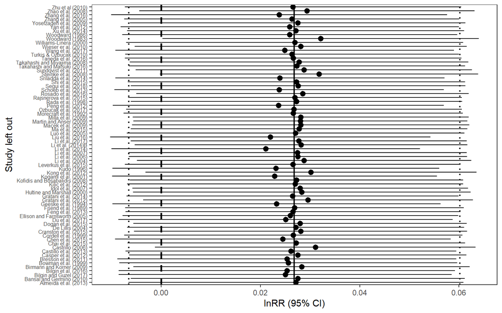

**Figure S8** Leave-one-out analysis showing overall effects $\beta_0$ and 95% CIs based on dataset with one study left out at a time from model fitting.

The distribution of overall effect ($\beta_0$) after deleting one study at a time also confirms no obvious outlier (**Figure S9**).

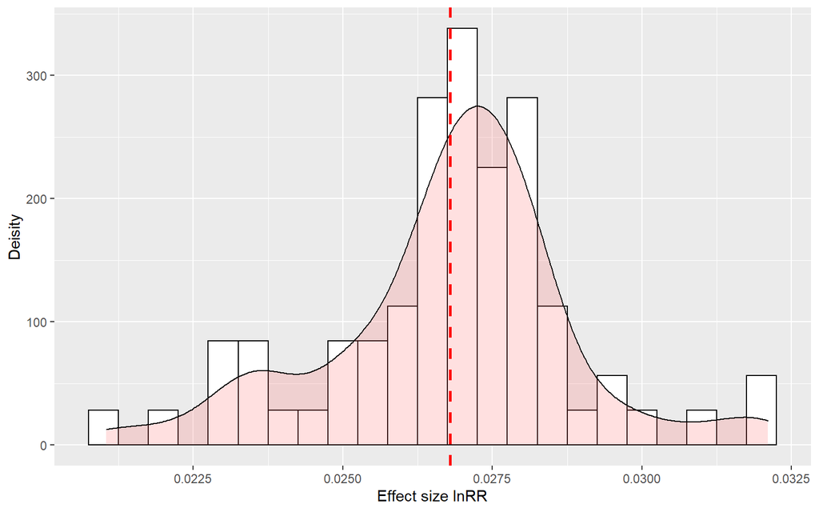

**Figure S9** Leave-one-out analysis showing distribution of overall effects $\beta_0$ based on dataset with one study left out at a time from model fitting.

There are also other diagnostic indices can be calculated from leave-one-out analysis, for example, Cook’s distance, difference between the regression coefficients (DFBETAS), and hat value.

- Cook’s distance = the Mahalanobis distance between the predicted (average) effect based on the full dataset and those based on the dataset with one study excluded from the model fitting. A study may be considered as ‘outlier’ if the lower-tail area of a chi-square distribution (with $p$ degrees = the number of model coefficients of freedom) cut off by the Cook’s distance is more than 50%.
- DFBETAS = changes in the predicted (average) effect for a specific study (quantified as standard deviations) after excluding the specific study from the model fitting. A study may be considered as ‘outlier’ the value of is more than 1.
- Halt value = the diagonal elements of the hat matrix that can transform the vector of observed effect into the vector of predicted. Halt value can determine the magnitude of residual based on dataset with a deleted study and therefore can help identify outlying studies. A study may be considered as ‘outlier’ if the halt value is more than $3(\frac {p} {N})$ (where $N$ = the number of studies).

There is point worth noting - these indices can be easily computed in `R`, but the above cut-offs are arbitrary. Therefore, if you want to use these indices, you really need informed judgments. Below we show how to calculate these indices.

Cook’s distance can be calculated via `cooks.distance()`:

```
cooks.distance(mod_ML_lnRR_VCV, cluster = Study_ID)
```

The calculation of DFBETAS and hat values can be done with `dfbetas()` and `hatvalues()`, respectively. The syntax is just as simple as that in `cooks.distance()`. Given the long time the calculation will take (our example dataset is very large), we do not show the results.

- **Quantitative critical appraisal**

Besides the qualitative methods to critically appraise the risk of bias of primary studies included in a meta-analysis, we recommend the quantitative methods. Meta-regression shown early provides a arsenal for quantitatively appraise the risk of primary studies. When compiling dataset, you need to extract variables related the risk-of-bias (*RoB*) characteristics, for example, blinding, randomization, and selective reporting. Then you can code these variables as moderators to be incorporated into a meta-regression. Unfortunately, at present, no environmental meta-analyses (at least our surveyed papers) have coded relevant moderators. Therefore, we are unable to provide an example to show implementation. The implementation is straightforward - you just need to use `mods` argument in `rma.mv()` function and supply *RoB* variables to the `mods` using a formula: `mods = ~ RoB`.

Our team (Shinichi Nakagawa) has published a paper that examined whether the selective reporting inflates the effect size estimates:

> Parker T H, Greig E I, Nakagawa S, et al. Subspecies status and methods explain strength of response to local versus foreign song by oscine birds in meta-analysis[J]. Animal Behaviour, 2018, 142: 1-17.

In this paper, we ran a meta-regression with selective reporting as a moderator and found that selective reporting inflated the effect size estimates. This paper exactly demonstrate the for **transparent reporting & open archiving** we contend in our main text. We refer to the relevant code archived at [Open Science Framework](https://osf.io/w2mvp/) to reproduce this quantitative critical appraisal if you think you are capable of conducting such an analysis with our illustration.

# Other relevant and advanced issues

## Missing data

According to our survey, many environmental meta-analyses have the issues of missing values for some of the primary studies:

1. missing standard deviations or sample sizes and associated with means, making effect size calculations in-feasible;
2. missing descriptions of study characteristics related variables, making coding of moderator variables impossible.

The usual practice of environmental meta-analysts to deal these issues is to delete the whole relevant studies. This will reduce the statistical power and precision of model coefficients (e.g., $\beta_0$ and $\beta_1$) due to the loss of sample size (in this case, the number of deleted studies), and limit the ability to reveal the drivers of heterogeneity between effect sizes due the loss of explanatory variables (i.e., moderators).

Here, we show how to impute missing standard deviation, which is a common phenomenon in environmental meta-analyses. We will introduce 2 readily implementable techniques to impute standard deviation. All the 2 methods are (partial) based on mean-variance relationship (strong correlation between standard deviation and mean).

The first method is simple multiple imputation, which imputes standard deviation using the coefficient of variation (CV) from all complete cases but uses resampling method to account for uncertainty when using CV from complete information;

The second method is an improved method for imputing standard deviations of lnRR, which imputes standard deviation using weighted average CV to improve the precision of sampling variance estimates. The reason why we introduce an imputation method for lnRR is that lnRR is the most commonly used effect size statistic in environmental meta-analyses (details see survey results in the main text).

Before formally showing implementation, we need to artificially create incomplete standard deviations in our dataset. we randomly select 20% of the studies and delete their standard deviations from both control (*sd_control*) and treatment groups (*sd_treatment*).

```
missing_SD <- dat2_Midolo_2019 # copy the dataset into missing_SD, which is used as the dataset for illustration of imputation method

set.seed(2022) # set the seed (for the random number generator) to make the following results fully reproducible; it is good practice to set the seed to make our results fully reproducible

stdies <- sample(unique(missing_SD$study_name), size = 0.2*(length(unique(missing_SD$study_name)))) # randomly sample 20% of studies

missing_SD[which(missing_SD$study_name %in% stdies), c("sd_treatment", "sd_control")] <- NA # create missingness of SD at the study level
```

Let’s have a look at the summary of artificially-created missingness in the dataset:

```
Summary of missingness:

        COLUMN PERCENT_MISSINGNESS IMPUTATIONS
      Study_ID                   0           0
    study_name                   0           0
       species                   0           0
         trait                   0           0
     treatment                   0           0
       control                   0           0
  sd_treatment                  12         159
    sd_control                  12         159
   n_treatment                   0           0
     n_control                   0           0
     elevation                   0           0
 elevation_log                   0           0
          lnRR                   0           0
         lnRRV                   0           0
         ES_ID                   0           0
       ess.var                   0           0
        ess.se                   0           0
          Year                   0           0
        Year.c                   0           0
     leave_out                   0           0

Total missingness: 1.2% (318 imputations needed)
```

```
                     COLUMN PERCENT_MISSINGNESS IMPUTATIONS
Study_ID           Study_ID             0.00000           0
study_name       study_name             0.00000           0
species             species             0.00000           0
trait                 trait             0.00000           0
treatment         treatment             0.00000           0
control             control             0.00000           0
sd_treatment   sd_treatment            12.28748         159
sd_control       sd_control            12.28748         159
n_treatment     n_treatment             0.00000           0
n_control         n_control             0.00000           0
elevation         elevation             0.00000           0
elevation_log elevation_log             0.00000           0
lnRR                   lnRR             0.00000           0
lnRRV                 lnRRV             0.00000           0
ES_ID                 ES_ID             0.00000           0
ess.var             ess.var             0.00000           0
ess.se               ess.se             0.00000           0
Year                   Year             0.00000           0
Year.c               Year.c             0.00000           0
leave_out         leave_out             0.00000           0
```

Below let’s show the implementation one by one.

- **Simple multiple imputation**

Multiple imputation methods are generally complex. Fully introducing Multiple imputation methods is beyond the scope of our paper - it deserves a independent paper. Many multiple imputation methods can be implemented via a powerful package `mice`. If you have interests in these advanced methods, you can look at the documentation of (`help(mice)`). Here, we introduce a simple multiple imputation method, which is based on the strong correlation between standard deviation and mean values and resort to resampling approach to make the imputed SD get rid of the uncertainty of imputation itself, such that the Type I error rate can be reduced. This method can be implemented via `impute_SD()` function in `metagear` package. The syntax for this is:

```
dat_simple <- impute_SD(missing_SD,
                        columnSDnames = c("sd_treatment", "sd_control"), # a string or list containing the labels of the column(s) with missing SD;
                        columnXnames = c("treatment", "control"), a string or list containing the labels of the column(s) with mean values for each SD.
                        method = "HotDeck")
```

```
Summary of missingness:

        COLUMN PERCENT_MISSINGNESS IMPUTATIONS
      Study_ID                   0           0
    study_name                   0           0
       species                   0           0
         trait                   0           0
     treatment                   0           0
       control                   0           0
  sd_treatment                   0           0
    sd_control                   0           0
   n_treatment                   0           0
     n_control                   0           0
     elevation                   0           0
 elevation_log                   0           0
          lnRR                   0           0
         lnRRV                   0           0
         ES_ID                   0           0
       ess.var                   0           0
        ess.se                   0           0
          Year                   0           0
        Year.c                   0           0
     leave_out                   0           0

Total missingness: 0% (0 imputations needed)
```

```
                     COLUMN PERCENT_MISSINGNESS IMPUTATIONS
Study_ID           Study_ID                   0           0
study_name       study_name                   0           0
species             species                   0           0
trait                 trait                   0           0
treatment         treatment                   0           0
control             control                   0           0
sd_treatment   sd_treatment                   0           0
sd_control       sd_control                   0           0
n_treatment     n_treatment                   0           0
n_control         n_control                   0           0
elevation         elevation                   0           0
elevation_log elevation_log                   0           0
lnRR                   lnRR                   0           0
lnRRV                 lnRRV                   0           0
ES_ID                 ES_ID                   0           0
ess.var             ess.var                   0           0
ess.se               ess.se                   0           0
Year                   Year                   0           0
Year.c               Year.c                   0           0
leave_out         leave_out                   0           0
```

We see that all the missing standard deviations (in both control and treatment groups) are imputed.

- **Improved imputation**

Our team (Shinichi Nakagawa and Malgorzata Lagisz) recently developed a tailored method for imputing missing standard deviations in lnRR. Our heavy simulation indicates that this method outputs the simple method based on the mean-variance relationship. Details see the following paper:

> Nakagawa, S., Noble, D. W., Lagisz, M., Spake, R., Viechtbauer, W., & Senior, A. M. (2022, May 19). A robust and readily implementable method for the meta-analysis of response ratios with and without missing standard deviations. https://doi.org/10.32942/osf.io/7thx9

We assume this method will help environmental meta-analysts a lot because lnRR is the mostly used effect size statistic in the field. In brief, this method is based on the weighted average CV rather than a simple average of CV. Using weighted average CV will give some data points carry more weight than others, such that the precision of sampling variance estimates can be improved. Below, we borrow two custom functions we wrote for the above paper to show implementation.

`cv_avg()` = compute the weighted average (square) CV within a study and the weighted average (square) CV between studies

`lnrr_laj()` = compute the point estimate of lnRR based on Taylor expansion

`v_lnrr_laj()` = compute the sampling variance for lnRR based on second order Taylor expansion

The full code is give below:

[output not shown]

We summarize the model estimates based the above two imputation methods in **Table S6**.

**Table S6** Comparison of estimates of model coefficients based on datasets with two simple imputation method and improved version.

|  | Complete dataset | Simple imputation method | Improved imputation method |
| --- | --- | --- | --- |
| Overall effect | 0.0297 | 0.0246 | -0.0272 |
| Standard error | 0.0194 | 0.0194 | 0.0193 |
| p-value | 0.13 | 0.2059 | 0.16 |
| Lower CI | -0.009 | -0.0135 | -0.0651 |
| Upper CI | 0.0684 | 0.0628 | 0.0108 |

## Complex non-independence

- **Multiple sources of non-independence**

Environmental meta-analytic datasets may have more clustering variables other than study identity causing statistical non-independence. As you could probably imagine, genus (*species*) could be such a clustering variable in an environmental dataset with multiple species included, as effect sizes derived from the same species are probably more similar to each other than effect sizes from different species due to similar genetics, shared history or phylogenetic relatedness. The multilevel model has a flexible random effects structure handling complex non-independence like, for example, taxonomic dependence, by adding associated clustering variables (e.g.,*species* ) as different levels of random effects:

$$z_{i} = \beta_{0} + a_{k[i]} + s_{k[i]} + \mu_{j[i]} + e_{i} + m_{i},
(19)$$
Argument `random` in `rma.mv` have an elegant solution to construct random effects structure. For example, if we want to account for both study and species (taxonomic) effects, we need to supply them via argument `random` and use `list()` to bind all these clustering variables together: `random = list(~ 1 | species, ~ 1 | Study_ID, ~ 1 | ES_ID)`. The complete code will be:

```
rma.mv(yi = lnRR,
       V = VCV,
       random = list(~1 | species, # add species identity as a random effect, which allows effect sizes vary between species;
                     ~1 | Study_ID, # add study identity as a random effect, which allows effect sizes vary between studies;
                     ~1 | ES_ID), # add effect size as a random effect, which allows effect sizes vary within studies.
       method = "REML",
       test = "t",
       data = dat2_Midolo_2019
      )
```

The output is:

```
Multivariate Meta-Analysis Model (k = 1294; method: REML)

   logLik   Deviance        AIC        BIC       AICc
-107.3514   214.7028   222.7028   243.3617   222.7338

Variance Components:

            estim    sqrt  nlvls  fixed    factor
sigma^2.1  0.0000  0.0064    109     no   species
sigma^2.2  0.0113  0.1064     71     no  Study_ID
sigma^2.3  0.0516  0.2272   1294     no     ES_ID

Test for Heterogeneity:
Q(df = 1293) = 65913.4258, p-val < .0001

Model Results:

estimate      se    tval    df    pval    ci.lb   ci.ub
  0.0268  0.0170  1.5730  1293  0.1160  -0.0066  0.0601

---
Signif. codes:  0 '***' 0.001 '**' 0.01 '*' 0.05 '.' 0.1 ' ' 1
```

We see that results given under **Variance Components** show variance components for each of 3 random effects, although there seems not heterogeneity between species.

**Note**

> a variable being a random-effect means that it varies across different environmental stressors, measurement methods, species, and ecosysten types. When a variable in a meta-analytic model is modeled as a random-effect, we believe that it contributes noise (variation) to the overall mean and thus has a random effect on the overall mean. For example, treating species as a random effect is assuming the true effects are heterogeneous within species and enables us to quantify how much variation there is among species. Rather, treating species as a fixed effect means that species levels are identical across different studies and thus have a systematic effect on the overall effect; this is equivalent to ask: do one species responds more to an environmental stressor than others?).
- **select a ‘best’ random effects structure**

Here, we introduce some recommended practices helping you decide a ‘best’ random effects structure to capture the hierarchical data structure (e.g., non-independence due to ‘clustering’, ‘nesting’, or ‘crossing’) you may have in your meta-analysis.

**Rule 1**

Investing whether the variable being a random effect is a true sources of heterogeneity according to your knowledge in your field - we are against solely using data-driven random effects structure without considering whether the tested variable has true heterogeneity.

**Rule 2**

A variable being a random effect should has levels > 5, such that the variance can be approximately unbiased estimated.

**Rule 3**

Examining whether adding the variable can improve model quality, such as fit statistics (e.g., AIC and BIC), goodness-of-fit (e.g., $R^2_{marginal}$).

Study (*Study_ID*) and effect size identities (*ES_ID*) are typical random effects for an environmental meta-analysis. Let’s use [1]‘s dataset empirically test this point and show how to select ’best’ random effects structure using information-theoretic approaches alongside likelihood ratio tests (implemented via function `anova.rma()`). There are three random effects candidates:

1. Effect size identity (*ES_ID*) - unique ID for each pairwise comparison for effect size calculation.
2. Study identity (*Study_ID*) - unique ID for each included primary study.
3. Species identity (*species*) - name of species included in the primary studies.

Let’s first fit a null model without including the above random effects candidates as the default reduced model:

```
null.re <- rma.mv(yi = lnRR,
                  V = VCV,
                  method = "ML", # Setting method = "ML" rather than "REML" when conduct model selection.
                  test = "t",
                  data = dat2_Midolo_2019
                  )
```

Then, add study identity (*Study_ID*) as a random effect via argument `random`:

```
study <- rma.mv(yi = lnRR,
                V = VCV,
                random = ~1 | Study_ID,
                method = "ML",
                test = "t",
                data = dat2_Midolo_2019
                )
```

Let’s conduct a likelihood ratio test to compare the two fitted models’ quality in terms of AIC, BIC, AICc, log-likelihood values:

```
anova.rma(null.re, study)
```

```
        df        AIC        BIC       AICc      logLik        LRT   pval
Full     2 47642.9931 47653.3240 47643.0024 -23819.4965
Reduced  1 60148.2005 60153.3660 60148.2036 -30073.1003 12507.2075 <.0001
                QE tau^2
Full    65913.4258    NA
Reduced 65913.4258    NA
```

In the same vein, we can examine whether *ES_ID* contributes to model fit:

```
es <- rma.mv(yi = lnRR,
             V = VCV,
             random = ~1 | ES_ID,
             method = "ML",
             test = "t",
             data = dat2_Midolo_2019
             )
```

```
anova.rma(null.re, es)
```

```
        df        AIC        BIC       AICc      logLik        LRT   pval
Full     2   270.8693   281.2003   270.8786   -133.4347
Reduced  1 60148.2005 60153.3660 60148.2036 -30073.1003 59879.3312 <.0001
                QE tau^2
Full    65913.4258    NA
Reduced 65913.4258    NA
```

From `AIC`, `LRT` and `pval` given under the above output, we know that model with *ES_ID* as a random effect (`Full`) is much better than model with without random effect (`Reduced`). Therefore, effect size identity is an important random effect our model should account for.

Next, lets compare whether a model with both *Study_ID* and *ES_ID* as random effects is better than a model with only *ES_ID* as a random effect:

```
study.es <- rma.mv(yi = lnRR,
                   V = VCV,
                   random = list(~1 | Study_ID,
                                 ~1 | ES_ID),
                   method = "ML",
                   test = "t",
                   data = dat2_Midolo_2019
                   )
```

```
anova.rma(study.es, es)
```

```
        df      AIC      BIC     AICc    logLik     LRT   pval         QE tau^2
Full     3 221.5487 237.0451 221.5673 -107.7743                65913.4258    NA
Reduced  2 270.8693 281.2003 270.8786 -133.4347 51.3207 <.0001 65913.4258    NA
```

As expected, full model has a smaller AIC value than that of reduced model, indicating that model defining the nested random effects (i.e., accounting for non-independence) structure using *Study_ID* and *ES_ID* has a better model fit (*Full*), compared to model ignoring non-independence (*Reduced*). Next, lets’ explore whether animal species identity is an important random effect. First add the coded variable *species* as a random effect term via argument `random`:

```
species.study.es <- rma.mv(yi = lnRR,
                              V = VCV,
                              random = list(~1 | species,
                                            ~1 | Study_ID,
                                            ~1 | ES_ID),
                             method = "ML",
                             test = "t",
                             data = dat2_Midolo_2019
                             )
```

```
anova.rma(species.study.es,study.es)
```

```
        df      AIC      BIC     AICc    logLik    LRT   pval         QE tau^2
Full     4 223.5484 244.2103 223.5794 -107.7742               65913.4258    NA
Reduced  3 221.5487 237.0451 221.5673 -107.7743 0.0003 0.9864 65913.4258    NA
```

```
   I2_Total  I2_species I2_Study_ID    I2_ES_ID
99.63048070  0.04486139 17.45782398 82.12779532
```

## Model selection and model-average inference

As said in our main text, model selection is a powerful method to:

- quantify the importance of moderators in explaining heterogeneity, which is useful when look for, for example, global drivers of environmental changes;
- multimodel inference, which can make model inferences about the moderators in the context of models with all possible combinations of moderators rather than a single ‘best’ model;
- multimodel predictions, which can predict (average) effects of a moderator and its CIs based on models with all possible combinations of moderators rather than a single ‘best’ model.

Below we show how to conduct model selection and multimodel inference using an information-theoretic approach (although $R^2$ based model selection is a reasonal option, it is not preferable here). To do so, `metafor` package needs to resort functionality from model-selection-dedicated packages like `MuMIn` and `glmulti`. We will use `MuMIn` package for illustration because the corresponding syntax is more straightforward and simpler than that of `glmulti`. Let’s still use dataset of [1]. This dataset only have two moderators, *elevation* and *trait*, so we include their interactions when illustrating. We would like to emphasize one point again - in your meta-analysis, you need to need to select your moderators based on their *priori* plausibility (predefined environmental questions you are going to address in your analyses) rather including many more moderators or removing them until you get a significant model.

- **Select best model**

By ‘best model’, we mean the acceptable amount of information loss when we use a fitted model to approximate the real data generating mechanism. To select the best model, first, we need fit a multilevel multi-moderator meta-analytic model with all plausible moderators (Equation 19; full model). Then, dredge the full model to produce models with all possible combination of moderators added to the full model (note that you need to use maximum likelihood (ML) rather than restricted ML; see early section for explanation):

```
mod.full <- rma.mv(yi = lnRR,
                   V = lnRRV,
                   mods = ~ trait * elevation_log,
                   random = list(~ 1 | Study_ID, ~ 1 | ES_ID),
                   method="ML",
                   test = "t",
                   data = dat2_Midolo_2019) # fit Equation 19 - multilevel multi-moderator meta-analytic model (full model with all plausible moderators).

eval(metafor:::.MuMIn) # use eval() function to extract helper functions from MuMIn and make them usable in metafor.

mod.candidate <- dredge(mod.full, beta = "none", evaluate = TRUE, rank = "AICc", trace=2) # dredge to produce all possible models
```

From **Table S7**, We see the fit statistics (log likelihood and AICc) from all possible models.

**Table S7** Fit statistics of models with different combinations of moderators included in the full model (Equation 19 - multilevel multi-moderator meta-analytic model).

|  | (Intercept) | elevation_log | trait | elevation_log:trait | df | logLik | AICc | delta | weight |
| --- | --- | --- | --- | --- | --- | --- | --- | --- | --- |
| 8 | + | -0.0199075344415985 | + | + | 16 | -74.6858267682605 | 181.79765197035 | 0 | 0.999992053889801 |
| 4 | + | 0.0263255446055064 | + |  | 10 | -92.6631149443186 | 205.497702998536 | 23.7000510281856 | 7.13831745291846e-06 |
| 3 | + |  | + |  | 9 | -95.8576848947814 | 209.855556705451 | 28.0579047351003 | 8.0779274608968e-07 |
| 2 | + | 0.0274565256959536 |  |  | 4 | -135.483043227364 | 278.99711826233 | 97.1994662919797 | 7.8234916208593e-22 |
| 1 | + |  |  |  | 3 | -138.730188562867 | 283.478981776897 | 101.681329806547 | 8.32101538995106e-23 |

Next step, let’s select a sets of best model. This can be done by using thumb of rules, for example, delta AICc <= 2:

```
subset(mod.candidate, delta <= 2, recalc.weights = FALSE)
```

```
Global model call: rma.mv(yi = lnRR, V = lnRRV, mods = ~trait * elevation_log, random = list(~1 |
    Study_ID, ~1 | ES_ID), data = dat2_Midolo_2019, method = "ML",
    test = "t", sparse = TRUE)
---
Model selection table
  (Int)  elv_log trt elv_log:trt df  logLik  AICc delta weight
8     + -0.01991   +           + 16 -74.686 181.8     0      1
Models ranked by AICc(x)
```

- **Model average**

```
summary(model.avg(mod.candidate))
```

```
Call:
model.avg(object = mod.candidate)

Component model call:
rma.mv(yi = lnRR, V = lnRRV, mods = ~<5 unique rhs>, random = list(~1 |
     Study_ID, ~1 | ES_ID), data = dat2_Midolo_2019, method = ML, test = t,
     sparse = TRUE)

Component models:
       df  logLik   AICc  delta weight
123    16  -74.69 181.80   0.00      1
12     10  -92.66 205.50  23.70      0
2       9  -95.86 209.86  28.06      0
1       4 -135.48 279.00  97.20      0
(Null)  3 -138.73 283.48 101.68      0

Term codes:
      elevation_log               trait elevation_log:trait
                  1                   2                   3

Model-averaged coefficients:
(full average)
                          Estimate Std. Error z value Pr(>|z|)
intrcpt                   0.115566   0.141088   0.819 0.412727
elevation_log            -0.019907   0.022636   0.879 0.379164
traitLA                  -0.097898   0.204791   0.478 0.632624
traitLMA                 -0.353229   0.188036   1.879 0.060310 .
traitNarea               -0.468677   0.185908   2.521 0.011701 *
traitNmass               -0.244480   0.165871   1.474 0.140505
traitPmass               -0.888061   0.248237   3.577 0.000347 ***
traitSLA                  0.131673   0.198118   0.665 0.506294
elevation_log:traitLA     0.003795   0.033306   0.114 0.909281
elevation_log:traitLMA    0.066417   0.030266   2.194 0.028204 *
elevation_log:traitNarea  0.088490   0.029835   2.966 0.003017 **
elevation_log:traitNmass  0.055879   0.026963   2.072 0.038222 *
elevation_log:traitPmass  0.182724   0.041437   4.410 1.04e-05 ***
elevation_log:traitSLA   -0.025019   0.032394   0.772 0.439920

(conditional average)
                          Estimate Std. Error z value Pr(>|z|)
intrcpt                   0.115566   0.141088   0.819 0.412727
elevation_log            -0.019907   0.022636   0.879 0.379163
traitLA                  -0.097898   0.204791   0.478 0.632624
traitLMA                 -0.353229   0.188036   1.879 0.060310 .
traitNarea               -0.468677   0.185908   2.521 0.011701 *
traitNmass               -0.244480   0.165871   1.474 0.140505
traitPmass               -0.888061   0.248237   3.577 0.000347 ***
traitSLA                  0.131673   0.198118   0.665 0.506294
elevation_log:traitLA     0.003795   0.033306   0.114 0.909281
elevation_log:traitLMA    0.066417   0.030266   2.194 0.028201 *
elevation_log:traitNarea  0.088491   0.029834   2.966 0.003016 **
elevation_log:traitNmass  0.055879   0.026962   2.073 0.038218 *
elevation_log:traitPmass  0.182726   0.041434   4.410 1.03e-05 ***
elevation_log:traitSLA   -0.025019   0.032394   0.772 0.439918
---
Signif. codes:  0 '***' 0.001 '**' 0.01 '*' 0.05 '.' 0.1 ' ' 1
```

The above output is showing all the estimates of model coefficients for moderators based on model average procedure. It is a typical format to show model estimates in `R`. The interpretation is quite easy. We also make a table (**Table S8**) showing results of model average based on `glmulti` for comparison. We see that the results are exactly the same.

**Table S8** The estimates of model slopes for moderators based on the model average inference method.

|  | Estimate | Stadard error | z-value | p-value | Lower CI | Upper CI | Importantce |
| --- | --- | --- | --- | --- | --- | --- | --- |
| intrcpt | 0.1156 | 0.1411 | 0.8191 | 0.4127 | -0.161 | 0.3921 | 1 |
| elevation_log | -0.0199 | 0.0226 | -0.8794 | 0.3792 | -0.0643 | 0.0245 | 1 |
| traitLA | -0.0979 | 0.2048 | -0.478 | 0.6326 | -0.4993 | 0.3035 | 1 |
| traitLMA | -0.3532 | 0.188 | -1.8785 | 0.0603 | -0.7218 | 0.0153 | 1 |
| traitNarea | -0.4687 | 0.1859 | -2.521 | 0.0117 | -0.833 | -0.1043 | 1 |
| traitNmass | -0.2445 | 0.1659 | -1.4739 | 0.1405 | -0.5696 | 0.0806 | 1 |
| traitPmass | -0.8881 | 0.2482 | -3.5775 | 0.0003 | -1.3746 | -0.4015 | 1 |
| traitSLA | 0.1317 | 0.1981 | 0.6646 | 0.5063 | -0.2566 | 0.52 | 1 |
| elevation_log:traitLA | 0.0038 | 0.0333 | 0.1139 | 0.9093 | -0.0615 | 0.0691 | 1 |
| elevation_log:traitLMA | 0.0664 | 0.0303 | 2.1944 | 0.0282 | 0.0071 | 0.1257 | 1 |

[output cut: 4 more lines]

## Scale dependence

Scale dependence is a widespread issue in the field of environmental sciences. Yet, it rarely has been accounted for in the current practice of environmental meta-analysis. The issue of scale dependence arises when unite of replication is a patch or plot (e.g., 100 $cm^2$ or 1 $km^2$). The issue roots in the intricate relationship among replicates (sample size), plot size and sampling variance $\nu_i$, which leads to a complex covariation among the three. Basically, scale dependence will lead to biased estimates of sampling variance, which violates a basic assumption of meta-analysis; sampling variance is known because they (partially) serve as weights to average effect sizes across studies.

There are no established solutions on this issue. Incidentally, our team (Rebecca Spake) has a comprehensive simulation paper investigating the scale dependence in the context of meta-analytic model:

> Spake R, Mori A S, Beckmann M, et al. Implications of scale dependence for cross‐study syntheses of biodiversity differences[J]. Ecology Letters, 2021, 24(2): 374-390.

Based on the results of this paper and our experience, we give three practical and easy-to-implement suggestions to mitigate the issue of scale dependence:

- 1. use lnRR rather than SMD as the effect size statistic to increase the accuracy of effect size and sampling variance estimates in terms of measurement of biodiversity, richness rather or species density.
- 2. conduct sensitivity analysis via, for example, fitting an unweighted model or using a different weighting scheme (e.g., weighting by an ordinal classification of study quality or non-parametric weighting) to get rid of the impact of inaccurate sampling variances; if using unweighted model, your dataset should be free of publication bias, otherwise you will get biased model coefficients
- 3. code the size of plot as a moderator and use meta-regression to control for its covariate effects on other moderators effects

Unfortunately, our survey did not find any dataset have coded plot size as a moderator (*Plot.Size*). Therefore, we are unable to provide a corresponding illustration. But remember the implementation is straightforward - you just need to use `mods` argument in `rma.mv()` function and supply *Plot.Size* variable to the `mods` using a formula: `mods = ~ Plot.Size`.

# License

This documented is licensed under the following license: [CC Attribution-Noncommercial-Share Alike 4.0 International](https://creativecommons.org/licenses/by-nc-sa/4.0/deed.en).

# Software and package versions

**R version 4.0.3 (2020-10-10)**

**Platform:** x86_64-w64-mingw32/x64 (64-bit)

**locale:** _LC_COLLATE=Chinese (Simplified)*China.936*, _LC_CTYPE=Chinese (Simplified)*China.936*, _LC_MONETARY=Chinese (Simplified)*China.936*, *LC_NUMERIC=C* and _LC_TIME=Chinese (Simplified)*China.936*

**attached base packages:** *grid*, *stats*, *graphics*, *grDevices*, *utils*, *datasets*, *methods* and *base*

**other attached packages:** *formatR(v.1.11)*, *pander(v.0.6.4)*, *gridGraphics(v.0.5-1)*, *png(v.0.1-7)*, *cowplot(v.1.1.1)*, *ggthemr(v.1.1.0)*, *ggalluvial(v.0.12.3)*, *visdat(v.0.5.3)*, *ggsignif(v.0.6.3)*, *plotly(v.4.9.4.1)*, *networkD3(v.0.4)*, *GoodmanKruskal(v.0.0.3)*, *mice(v.3.13.0)*, *patchwork(v.1.1.1)*, *metagear(v.0.7)*, *glmulti(v.1.0.8)*, *leaps(v.3.1)*, *rJava(v.1.0-4)*, *MuMIn(v.1.43.17)*, *orchaRd(v.2.0)*, *clubSandwich(v.0.5.3)*, *metafor(v.3.4-0)*, *metadat(v.1.2-0)*, *Matrix(v.1.2-18)*, *readxl(v.1.3.1)*, *ggpubr(v.0.4.0)*, *DT(v.0.19)*, *here(v.1.0.1)*, *forcats(v.0.5.1)*, *stringr(v.1.4.0)*, *dplyr(v.1.0.7)*, *purrr(v.0.3.4)*, *readr(v.2.0.1)*, *tidyr(v.1.1.3)*, *tibble(v.3.1.4)*, *ggplot2(v.3.3.5)*, *tidyverse(v.1.3.1)*, *palmerpenguins(v.0.1.0)*, *rmdformats(v.1.0.3)* and *knitr(v.1.37)*

**loaded via a namespace (and not attached):** *backports(v.1.2.1)*, *plyr(v.1.8.6)*, *igraph(v.1.2.6)*, *lazyeval(v.0.2.2)*, *splines(v.4.0.3)*, *crosstalk(v.1.1.1)*, *TH.data(v.1.1-0)*, *digest(v.0.6.27)*, *htmltools(v.0.5.2)*, *fansi(v.0.5.0)*, *magrittr(v.2.0.1)*, *tzdb(v.0.1.2)*, *openxlsx(v.4.2.4)*, *modelr(v.0.1.8)*, *sandwich(v.3.0-1)*, *colorspace(v.2.0-0)*, *rvest(v.1.0.1)*, *haven(v.2.4.3)*, *xfun(v.0.29)*, *tcltk(v.4.0.3)*, *crayon(v.1.4.1)*, *jsonlite(v.1.7.2)*, *survival(v.3.2-7)*, *zoo(v.1.8-9)*, *glue(v.1.4.2)*, *gtable(v.0.3.0)*, *emmeans(v.1.6.3)*, *car(v.3.0-11)*, *abind(v.1.4-5)*, *scales(v.1.1.1)*, *mvtnorm(v.1.1-2)*, *DBI(v.1.1.1)*, *rstatix(v.0.7.0)*, *Rcpp(v.1.0.8.3)*, *viridisLite(v.0.4.0)*, *xtable(v.1.8-4)*, *latex2exp(v.0.9.4)*, *foreign(v.0.8-81)*, *stats4(v.4.0.3)*, *htmlwidgets(v.1.5.3)*, *httr(v.1.4.2)*, *ellipsis(v.0.3.2)*, *farver(v.2.1.0)*, *pkgconfig(v.2.0.3)*, *sass(v.0.4.0)*, *dbplyr(v.2.1.1)*, *utf8(v.1.2.2)*, *labeling(v.0.4.2)*, *tidyselect(v.1.1.1)*, *rlang(v.0.4.10)*, *munsell(v.0.5.0)*, *cellranger(v.1.1.0)*, *tools(v.4.0.3)*, *cli(v.3.0.1)*, *generics(v.0.1.0)*, *pacman(v.0.5.1)*, *broom(v.0.7.9)*, *mathjaxr(v.1.2-0)*, *evaluate(v.0.14)*, *fastmap(v.1.1.0)*, *yaml(v.2.2.1)*, *fs(v.1.5.0)*, *zip(v.2.2.0)*, *nlme(v.3.1-151)*, *xml2(v.1.3.2)*, *compiler(v.4.0.3)*, *rstudioapi(v.0.13)*, *beeswarm(v.0.4.0)*, *curl(v.4.3.2)*, *reprex(v.2.0.1)*, *bslib(v.0.3.0)*, *stringi(v.1.7.4)*, *highr(v.0.9)*, *lattice(v.0.20-41)*, *vctrs(v.0.3.8)*, *pillar(v.1.6.2)*, *lifecycle(v.1.0.0)*, *jquerylib(v.0.1.4)*, *estimability(v.1.3)*, *data.table(v.1.14.0)*, *R6(v.2.5.1)*, *bookdown(v.0.24)*, *rio(v.0.5.27)*, *vipor(v.0.4.5)*, *codetools(v.0.2-18)*, *MASS(v.7.3-54)*, *assertthat(v.0.2.1)*, *rprojroot(v.2.0.2)*, *withr(v.2.4.2)*, *multcomp(v.1.4-17)*, *mgcv(v.1.8-33)*, *hms(v.1.1.0)*, *coda(v.0.19-4)*, *rmarkdown(v.2.11)*, *carData(v.3.0-4)*, *lubridate(v.1.7.10)* and *ggbeeswarm(v.0.6.0)*

# References

1. Midolo G, De Frenne P, Hölzel N, Wellstein C. Global patterns of intraspecific leaf trait responses to elevation. Global Change Biology. Wiley Online Library; 2019;25:2485–98.

2. Nakagawa S, Schielzeth H. A general and simple method for obtaining R2 from generalized linear mixed-effects models. Methods in ecology and evolution. Wiley Online Library; 2013;4:133–42.